*This page was rendered on: 2023-04-12 15:10:26*

*Authors: Tuyen Huynh (tuyenhn@oucru.org) and Manh Nguyen (manhnd@oucru.org)*

# Introduction

This Rmarkdown file performs data science steps on raw anonymized Dengue incidence data from Ho Chi Minh City and Hanoi, between 2017-2022. These steps will help you understand the raw data and how we opted to work with it. The data comes as 2 folders, one for Hanoi and one for Ho Chi Minh City, which we have removed most personal identifiable information, the rest will be removed in this file.

# Library imports

- We will be following the `tidyverse` convention with its packages and functions.

```r
library(tidyverse)
library(magrittr)
library(fs)
library(lubridate)
library(janitor)
library(patchwork)
library(progress)
library(osrm)
```

```r
library(sf)
library(plotly)
```

- knitr options

```r
knitr::opts_chunk$set(message = FALSE)
```

# I. Data ingestion and aggregation

*Note: Ingested data are **mostly** removed of personal identifiable information*

## a. Data ingestion

- First, we will need to get the paths of all the data files.

```r
path <- "C:/Users/tuyenhn/Documents/dart/epidemiological data/incidence_data"

# For HCMC
hcmc_paths <- dir_ls(
  sprintf("%s/hcmc", path),
  recurse = TRUE, regexp = "Danh.*\\.csv"
)
# For Hanoi
hanoi_paths <- dir_ls(
  sprintf("%s/hanoi", path),
  recurse = TRUE, regexp = "Danh.*\\.csv"
)
hcmc_paths %>% head(5)
```

```
## C:/Users/tuyenhn/Documents/dart/epidemiological data/incidence_data/hcmc/2017/Tháng 1-4/Danh sách trường hợp bệnh_20230113172737.csv
## C:/Users/tuyenhn/Documents/dart/epidemiological data/incidence_data/hcmc/2017/Tháng 10/Danh sách trường hợp bệnh_20230113174811.csv
## C:/Users/tuyenhn/Documents/dart/epidemiological data/incidence_data/hcmc/2017/Tháng 11/Danh sách trường hợp bệnh_20230113175024.csv
## C:/Users/tuyenhn/Documents/dart/epidemiological data/incidence_data/hcmc/2017/Tháng 12/Danh sách trường hợp bệnh_20230113175147.csv
## C:/Users/tuyenhn/Documents/dart/epidemiological data/incidence_data/hcmc/2017/Tháng 5/Danh sách trường hợp bệnh_20230113173401.csv
```

## b. Data aggregation

- Then we will aggregate all of them through row-binding for each respective city.
- We will also define the column types through a [compact string](https://readr.tidyverse.org/articles/readr.html#available-column-specifications). Reading all columns as character makes it easier for us to normalize and clean the data later, while also cancel out the column type guessing from `readr`.

```r
# aggregate <- function(paths) {
#   pb <- progress_bar$new(total = length(paths))
#   df <- tibble()
#   for (fname in paths) {
#     pb$tick()
#     temp <- read_csv(
#       fname,
#       show_col_types = FALSE, progress = FALSE,
#       col_types = paste0(rep("c", 30), collapse = ""),
#       col_select = -c(`...31`)
#     )
#     df %<>% bind_rows(temp)
#   }
#   return(df)
# }

# incidence_hcmc <- aggregate(hcmc_paths)
# incidence_hanoi <- aggregate(hanoi_paths)
# incidence_hcmc %>% head(5)

incidence_hcmc <- read_rds("incidence_hcmc_after_aggregate.rds")
incidence_hanoi <- read_rds("incidence_hanoi_after_aggregate.rds")
incidence_hcmc %>% head(5)
```

```
## # A tibble: 5 × 30
##   `Mã số`      Ngày …¹ Nghề …² Nơi l…³ Dân t…⁴ Giới …⁵ Tỉnh  Huyện Xã    Chẩn …⁶
##   <chr>        <chr>   <chr>   <chr>   <chr>   <chr>   <chr> <chr> <chr> <chr>
## 1 11315231772… 01/07/… Khác    <NA>    Kinh    Nam     Nam … Huyệ… Xã G… Sốt xu…
## 2 70139131418… 10/07/… Khác    <NA>    Kinh    Nam     TP. … Huyệ… Xã T… Sốt xu…
## 3 70139131555… 25/12/… Sinh v… <NA>    Kinh    Nam     TP. … Huyệ… Xã T… Sốt xu…
## 4 70139131626… 10/10/… Khác    <NA>    Kinh    Nam     TP. … Huyệ… Xã T… Sốt xu…
## 5 70139131729… 10/09/… Khác    <NA>    Kinh    Nam     TP. … Huyệ… Xã T… Sốt xu…
## # … with 20 more variables: `Phân độ bệnh` <chr>,
## #   `Chẩn đoán bệnh kèm theo` <chr>, `Phân loại chẩn đoán` <chr>,
## #   `Lấy mẫu xét nghiệm` <chr>, `Ngày lấy mẫu` <chr>,
## #   `Đơn vị thực hiện xét nghiệm` <chr>, `Loại xét nghiệm` <chr>,
## #   `Kết quả xét nghiệm` <chr>, `Ghi chú` <chr>, `Tình trạng hiện nay` <chr>,
## #   `Tiền sử dịch tễ` <chr>, `Ngày khởi phát` <chr>,
## #   `Ngày nhập viện/khám` <chr>, `Ngày ra viện/chuyển viện/tử vong` <chr>, …
```

```r
incidence_hanoi %>% head(5)
```

```
## # A tibble: 5 × 30
##   `Mã số`      Ngày …¹ Nghề …² Nơi l…³ Dân t…⁴ Giới …⁵ Tỉnh  Huyện Xã    Chẩn …⁶
##   <chr>        <chr>   <chr>   <chr>   <chr>   <chr>   <chr> <chr> <chr> <chr>
## 1 10143131744… 14/10/… Nông d… <NA>    Kinh    Nam     Hà N… Huyệ… Xã B… Sốt xu…
## 2 10143151744… 10/05/… Sinh v… <NA>    Kinh    Nữ      Hà N… Huyệ… Xã C… Sốt xu…
## 3 10121071669… 25/02/… Trí th… <NA>    Kinh    Nữ      Hà N… Quận… Phườ… Sốt xu…
## 4 85565291838… 10/08/… Trí th… <NA>    Kinh    Nữ      Hà N… Quận… Phườ… Sốt xu…
## 5 85565281838… 05/08/… Công n… <NA>    Kinh    Nam     Hà N… Quận… Phườ… Sốt xu…
## # … with 20 more variables: `Phân độ bệnh` <chr>,
## #   `Chẩn đoán bệnh kèm theo` <chr>, `Phân loại chẩn đoán` <chr>,
## #   `Lấy mẫu xét nghiệm` <chr>, `Ngày lấy mẫu` <chr>,
## #   `Đơn vị thực hiện xét nghiệm` <chr>, `Loại xét nghiệm` <chr>,
## #   `Kết quả xét nghiệm` <chr>, `Ghi chú` <chr>, `Tình trạng hiện nay` <chr>,
## #   `Tiền sử dịch tễ` <chr>, `Ngày khởi phát` <chr>,
## #   `Ngày nhập viện/khám` <chr>, `Ngày ra viện/chuyển viện/tử vong` <chr>, …
```

# II. Data cleaning and translation

## a. Merging

- For ease of coding in the following steps, we will merge the Ho Chi Minh and Hanoi dataframes together into one singular dataframe. The ids from each dataframe will be saved so that we can split them back again at the end if needed.

```r
# save the ids for later
# hcmc_incidence_ids <- incidence_hcmc$`Mã số`
# hanoi_incidence_ids <- incidence_hanoi$`Mã số`

# merging
incidence_df <- incidence_hcmc %>% bind_rows(incidence_hanoi)
```

*Mã số = ID*

## b. Column translation

- To make it easier in later steps, we will translate column names to English here.

```r
eng_cols <- c(
  id = "Mã số",
  dob = "Ngày sinh",
  occupation = "Nghề nghiệp",
  place_of_occupation = "Nơi làm việc/ Học tập",
  ethnicity = "Dân tộc",
  gender = "Giới tính",
  province = "Tỉnh",
  district = "Huyện",
  commune = "Xã",
  main_diag = "Chẩn đoán chính",
  severity = "Phân độ bệnh",
  comorbidity_diag = "Chẩn đoán bệnh kèm theo",
  diagnosis = "Phân loại chẩn đoán",
  test_taken = "Lấy mẫu xét nghiệm",
  date_tested = "Ngày lấy mẫu",
  testing_unit = "Đơn vị thực hiện xét nghiệm",
  testing_type = "Loại xét nghiệm",
  testing_result = "Kết quả xét nghiệm",
  notes = "Ghi chú",
  current_condition = "Tình trạng hiện nay",
  epidemiology_history = "Tiền sử dịch tễ",
  date_symptom_onset = "Ngày khởi phát",
  date_admitted = "Ngày nhập viện/khám",
  date_discharged_transferred_died = "Ngày ra viện/chuyển viện/tử vong",
  symptom_diagnosis = "Chẩn đoán biến chứng",
  reported_unit = "Đơn vị báo cáo",
  reported_unit_province = "Tỉnh đơn vị báo cáo",
  treated_unit = "Cơ sở điều trị",
  reported_time = "Thời gian báo cáo",
  latest_status_change = "Tình trạng thay đổi gần nhất"
)

incidence_df %<>% rename(!!!eng_cols)
incidence_df %>% head(5)
```

```
## # A tibble: 5 × 30
##   id        dob   occup…¹ place…² ethni…³ gender provi…⁴ distr…⁵ commune main_…⁶
##   <chr>     <chr> <chr>   <chr>   <chr>   <chr>  <chr>   <chr>   <chr>   <chr>
## 1 11315231… 01/0… Khác    <NA>    Kinh    Nam    Nam Đị… Huyện … Xã Gia… Sốt xu…
## 2 70139131… 10/0… Khác    <NA>    Kinh    Nam    TP. H.… Huyện … Xã Tân… Sốt xu…
## 3 70139131… 25/1… Sinh v… <NA>    Kinh    Nam    TP. H.… Huyện … Xã Tân… Sốt xu…
## 4 70139131… 10/1… Khác    <NA>    Kinh    Nam    TP. H.… Huyện … Xã Tân… Sốt xu…
## 5 70139131… 10/0… Khác    <NA>    Kinh    Nam    TP. H.… Huyện … Xã Tân… Sốt xu…
## # … with 20 more variables: severity <chr>, comorbidity_diag <chr>,
## #   diagnosis <chr>, test_taken <chr>, date_tested <chr>, testing_unit <chr>,
## #   testing_type <chr>, testing_result <chr>, notes <chr>,
## #   current_condition <chr>, epidemiology_history <chr>,
## #   date_symptom_onset <chr>, date_admitted <chr>,
## #   date_discharged_transferred_died <chr>, symptom_diagnosis <chr>,
## #   reported_unit <chr>, reported_unit_province <chr>, treated_unit <chr>, …
```

- We will also convert all characters to lower case letter since this will help with normalizing the data and further steps.

```r
incidence_df %<>% mutate_all(.funs = tolower)
incidence_df %>% head(5)
```

```
## # A tibble: 5 × 30
##   id        dob   occup…¹ place…² ethni…³ gender provi…⁴ distr…⁵ commune main_…⁶
##   <chr>     <chr> <chr>   <chr>   <chr>   <chr>  <chr>   <chr>   <chr>   <chr>
## 1 11315231… 01/0… khác    <NA>    kinh    nam    nam đị… huyện … xã gia… sốt xu…
## 2 70139131… 10/0… khác    <NA>    kinh    nam    tp. h.… huyện … xã tân… sốt xu…
## 3 70139131… 25/1… sinh v… <NA>    kinh    nam    tp. h.… huyện … xã tân… sốt xu…
## 4 70139131… 10/1… khác    <NA>    kinh    nam    tp. h.… huyện … xã tân… sốt xu…
## 5 70139131… 10/0… khác    <NA>    kinh    nam    tp. h.… huyện … xã tân… sốt xu…
## # … with 20 more variables: severity <chr>, comorbidity_diag <chr>,
## #   diagnosis <chr>, test_taken <chr>, date_tested <chr>, testing_unit <chr>,
## #   testing_type <chr>, testing_result <chr>, notes <chr>,
## #   current_condition <chr>, epidemiology_history <chr>,
## #   date_symptom_onset <chr>, date_admitted <chr>,
## #   date_discharged_transferred_died <chr>, symptom_diagnosis <chr>,
## #   reported_unit <chr>, reported_unit_province <chr>, treated_unit <chr>, …
```

## c. Type conversion

- Here we will convert dates and other numerical values from character vectors into its intended data type.
- First we will check if the dates are cleanly formatted.

```r
# convert character vectors to date objects
# extract years as well
incidence_df %<>%
  mutate(
    across(
      c(
        dob, date_admitted, date_symptom_onset,
        date_discharged_transferred_died
      ),
      .fns = dmy
    )
  ) %>%
  mutate(
    year_dob = year(dob),
    year_admitted = year(date_admitted),
    year_symptom_onset = year(date_symptom_onset),
    year_discharged_transferred_died = year(date_discharged_transferred_died)
  )

incidence_df %>%
  select(
    year_dob,
    year_admitted,
    year_symptom_onset,
    year_discharged_transferred_died
  ) %>%
  summary()
```

```
##     year_dob    year_admitted  year_symptom_onset
##  Min.   : 988   Min.   : 217   Min.   : 201
##  1st Qu.:1984   1st Qu.:2018   1st Qu.:2018
##  Median :1996   Median :2019   Median :2019
##  Mean   :1994   Mean   :2019   Mean   :2019
##  3rd Qu.:2007   3rd Qu.:2022   3rd Qu.:2021
##  Max.   :2022   Max.   :3021   Max.   :2219
##                                NA's   :6661
##  year_discharged_transferred_died
##  Min.   :1899
##  1st Qu.:2017
##  Median :2019
##  Mean   :2019
##  3rd Qu.:2020
##  Max.   :2023
##  NA's   :259494
```

```r
incidence_df %>%
  mutate(
    is_in_range = case_when(
      year_admitted > 2023 ~ "out range",
      year_admitted < 2016 ~ "out range",
      year_symptom_onset > 2023 ~ "out range",
      year_symptom_onset < 2016 ~ "out range",
      year_discharged_transferred_died > 2023 ~ "out range",
      year_discharged_transferred_died < 2016 ~ "out range",
      .default = "in range"
    )
  ) %>%
  group_by(is_in_range) %>%
  summarise(total = n())
```

```
## # A tibble: 2 × 2
##   is_in_range  total
##   <chr>        <int>
## 1 in range    364484
## 2 out range      123
```

- For admission, sympton onset and discharged/transferred/died years, only 123 rows are outside of the predefined range. Since this is miniscule compared to the data size, we’ll remove these rows from further analysis.

```r
incidence_df %>%
  count(year_dob) %>%
  mutate(
    is_in_range = case_when(
      year_dob < 1923 ~ "out range",
      year_dob > 2023 ~ "out range",
      .default = "in range"
    )
  ) %>%
  group_by(is_in_range) %>%
  summarise(total = sum(n))
```

```
## # A tibble: 2 × 2
##   is_in_range  total
##   <chr>        <int>
## 1 in range    364458
## 2 out range      149
```

- Same story for birth years, only 149 rows are outside of the predefined range. We’ll also remove these rows from further analysis.

```r
incidence_df %<>%
  filter(
    year_dob <= 2023, year_dob >= 1923
  ) %>%
  filter(
    year_admitted <= 2023, year_admitted >= 2016
  ) %>%
  filter(
    (year_symptom_onset <= 2023 & year_symptom_onset >= 2016) | is.na(year_symptom_onset)
  ) %>%
  filter(
    (year_discharged_transferred_died <= 2023 &
      year_discharged_transferred_died >= 2016) |
      is.na(year_discharged_transferred_died)
  )
```

- Now, we have converted date data from character vectors into date objects, while also went on a little detour to clean the date data.

## c. Deduplications

- Now, let’s do a check to see if there are any (fully-)duplicated rows.

```r
incidence_df %>%
  get_dupes() %>%
  head(10)
```

```
## # A tibble: 10 × 35
##    id          dob        occup…¹ place…² ethni…³ gender provi…⁴ distr…⁵ commune
##    <chr>       <date>     <chr>   <chr>   <chr>   <chr>  <chr>   <chr>   <chr>
##  1 1014907309… 1977-08-23 khác    <NA>    kinh    nam    tp. h.… quận 12 phường…
##  2 1014907309… 1977-08-23 khác    <NA>    kinh    nam    tp. h.… quận 12 phường…
##  3 1014907309… 1977-08-23 khác    <NA>    kinh    nam    tp. h.… quận 12 phường…
##  4 1010101302… 2020-06-17 trẻ < … <NA>    kinh    nam    hà nội  quận b… phường…
##  5 1010101302… 2020-06-17 trẻ < … <NA>    kinh    nam    hà nội  quận b… phường…
##  6 1010101311… 1964-03-08 hưu trí <NA>    kinh    nữ     hà nội  quận b… phường…
##  7 1010101311… 1964-03-08 hưu trí <NA>    kinh    nữ     hà nội  quận b… phường…
##  8 1010101312… 1994-07-15 khác    <NA>    kinh    nam    hà nội  quận b… phường…
##  9 1010101312… 1994-07-15 khác    <NA>    kinh    nam    hà nội  quận b… phường…
## 10 1010101313… 2016-04-07 khác    <NA>    kinh    nữ     hà nội  quận b… phường…
## # … with 26 more variables: main_diag <chr>, severity <chr>,
## #   comorbidity_diag <chr>, diagnosis <chr>, test_taken <chr>,
## #   date_tested <chr>, testing_unit <chr>, testing_type <chr>,
## #   testing_result <chr>, notes <chr>, current_condition <chr>,
## #   epidemiology_history <chr>, date_symptom_onset <date>,
## #   date_admitted <date>, date_discharged_transferred_died <date>,
## #   symptom_diagnosis <chr>, reported_unit <chr>, …
```

```r
incidence_df %>%
  group_by(across(everything())) %>%
  summarise(dupes = n()) %>%
  filter(dupes > 1) %>%
  ungroup() %>%
  count(dupes)
```

```
## # A tibble: 2 × 2
##   dupes     n
##   <int> <int>
## 1     2 31216
## 2     3     1
```

- There are 31216 records that have a duplicate and 1 record has 2 duplicates. Now we remove those duplicates.

```r
cat("Before duplication removal:", nrow(incidence_df), "rows \n")
```

```
## Before duplication removal: 364335 rows
```

```r
incidence_df %<>% distinct()

cat("\nAfter duplication removal:", nrow(incidence_df), "rows \n")
```

```
##
## After duplication removal: 333117 rows
```

*Upon further manual inspection, it seems like these duplication are a result of file duplication, i.e. some folder has 2 incidence files that are exactly the same.*

- We also found there are ID duplicates where the duplication only happens in the ID of the incidence. We hypothesize that this might be because the surveillance system assigns each patient a unique ID of their own. Some of these cases are either second infections, patients being referred/transferred to another treating unit, or just simply updates from past incidence reports.

```r
incidence_df %>%
  group_by(id) %>%
  summarise(dupes = n()) %>%
  filter(dupes > 1) %>%
  count(dupes)
```

```
## # A tibble: 7 × 2
##   dupes     n
##   <int> <int>
## 1     2  9336
## 2     3   970
## 3     4   195
## 4     5    54
## 5     6     7
## 6     7     4
## 7   237     1
```

- Above you can see the count of number of duplicates. Curiously, we have an ID where it is duplicated 237 times. This requires further investigation.
- Before that, we will need to check if any of these duplicates are secondary infections. The criteria for records to be considered as secondary infections would be that they *use the same ID*, and has *more than 30 days between reported times*. Records that have the same ID but were reported within 30 days of each other would be considered an update of the first incidence report, not a new separate incidence.

```r
# parse `reported_time` into a datetime object
incidence_df %<>%
  mutate(
    reported_time = parse_date_time2(reported_time, "HMSdmY")
  )

# dataframe of duplicates with date difference based on time of incidence report
datediff_df <- incidence_df %>%
  group_by(id) %>%
  filter(n() > 1) %>%
  arrange(reported_time) %>%
  mutate(
    reported_time_diff = difftime(
      reported_time,
      lag(reported_time),
      units = "days"
    ) %>%
      as.integer()
  )

datediff_df %>%
  filter(reported_time_diff > 30)
```

```
## # A tibble: 1,571 × 35
## # Groups:   id [1,552]
##    id          dob        occup…¹ place…² ethni…³ gender provi…⁴ distr…⁵ commune
##    <chr>       <date>     <chr>   <chr>   <chr>   <chr>  <chr>   <chr>   <chr>
##  1 1010817145… 2008-09-21 sinh v… <NA>    kinh    nữ     hà nội  quận h… phường…
##  2 7013505155… 2008-03-11 sinh v… <NA>    kinh    nữ     tp. h.… huyện … xã tân…
##  3 7012707669… 2015-11-23 trẻ < … <NA>    kinh    nữ     tp. h.… quận t… phường…
##  4 7013501169… 1982-02-01 khác    <NA>    kinh    nam    tp. h.… huyện … thị tr…
##  5 7011909166… 2004-04-30 sinh v… <NA>    kinh    nữ     tp. h.… quận 10 phường…
##  6 7013915198… 2006-07-01 trẻ < … <NA>    kinh    nữ     tp. h.… huyện … xã bìn…
##  7 7011705142… 1998-09-02 sinh v… <NA>    kinh    nữ     tp. h.… quận 9  phường…
##  8 7011705144… 1981-01-01 công n… <NA>    kinh    nữ     tp. h.… quận 9  phường…
##  9 7011901180… 2016-06-21 trẻ < … <NA>    kinh    nữ     tp. h.… quận 10 phường…
## 10 7013709168… 2016-06-20 trẻ < … <NA>    kinh    nam    tp. h.… huyện … xã ðôn…
## # … with 1,561 more rows, 26 more variables: main_diag <chr>, severity <chr>,
## #   comorbidity_diag <chr>, diagnosis <chr>, test_taken <chr>,
## #   date_tested <chr>, testing_unit <chr>, testing_type <chr>,
## #   testing_result <chr>, notes <chr>, current_condition <chr>,
## #   epidemiology_history <chr>, date_symptom_onset <date>,
## #   date_admitted <date>, date_discharged_transferred_died <date>,
## #   symptom_diagnosis <chr>, reported_unit <chr>, …
```

- From this, we also discover that there are also incidence updates for secondary infections. So, to solve this we will
  - group all reported incidences together by ID, then split them into groups depends on the time of report.
  - This will split first infection and its case updates into one group, and the second infection and its case updates into another group.
  - From these groups, we will then extract the latest report only, and use it to represent the incidence as a whole.
  - This is not the most effective way but it is a good way to perform deduplications against incidence updates, as well as generalized enough to account for tertiary and quarternary infections. The remaining incidence reports will be unique for each patient and each infection.

A visualization of this problem:

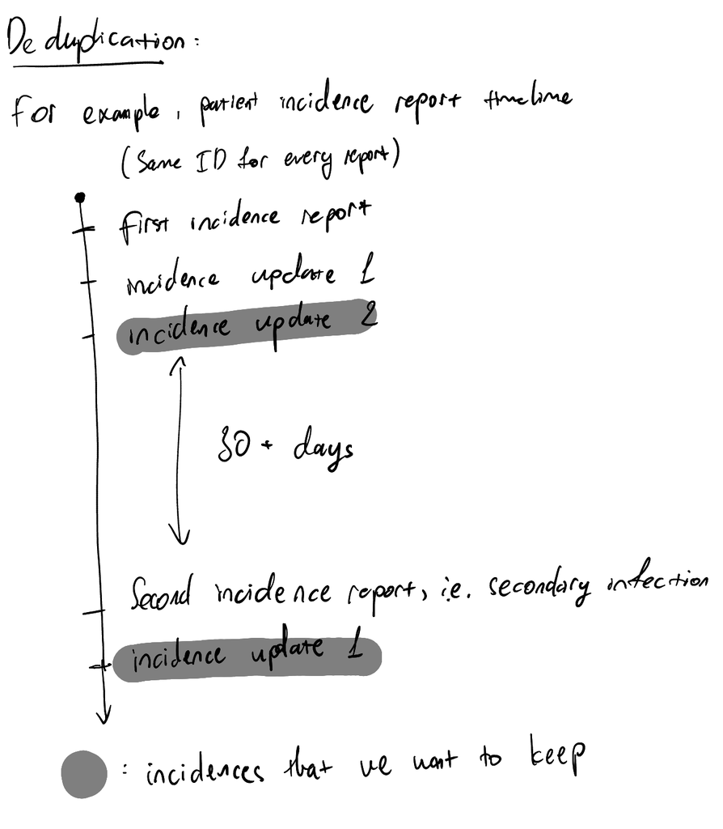

```r
cat("Before duplication removal:", nrow(incidence_df), "rows \n")
```

```
## Before duplication removal: 333117 rows
```

```r
incidence_df %<>%
  arrange(id, date_admitted) %>%
  mutate(
    group = cumsum(
      c(1, diff(date_admitted) > 30 | diff(id %>% as.numeric()) != 0)
    )
  ) %>%
  group_by(id, group) %>%
  slice_tail(n = 1) %>%
  ungroup() %>%
  select(-group)

cat("\nAfter duplication removal:", nrow(incidence_df), "rows \n")
```

```
##
## After duplication removal: 322349 rows
```

- After this process, we can now see the distribution incidences as first, secondary, etc. infections.

```r
incidence_df %>%
  group_by(id) %>%
  summarise(total_infections = n()) %>%
  count(total_infections)
```

```
## # A tibble: 4 × 2
##   total_infections      n
##              <int>  <int>
## 1                1 319172
## 2                2   1544
## 3                3     28
## 4                5      1
```

```r
incidence_df %>%
  group_by(id) %>%
  filter(n() > 4) %>%
  select(id, date_admitted, reported_time)
```

```
## # A tibble: 5 × 3
## # Groups:   id [1]
##   id              date_admitted reported_time
##   <chr>           <date>        <dttm>
## 1 701393330786452 2022-05-05    2022-05-06 09:22:32
## 2 701393330786452 2022-06-05    2022-05-09 14:05:03
## 3 701393330786452 2022-08-05    2022-05-10 10:30:47
## 4 701393330786452 2022-09-05    2022-05-10 10:32:54
## 5 701393330786452 2022-11-05    2022-05-12 09:05:37
```

## d. Nulls

- Here, we will check if there are any nulls in the data both row-wise and column-wise.
- Starting with checking the columns, we will go through each column, sum up the number of null values, and its percentage. Then, we sort the percentages in descending order to see which column is missing most of its data.

```r
incidence_df %>%
  summarise(across(everything(), ~ sum(is.na(.)))) %>%
  t() %>%
  enframe() %>%
  mutate(
    col = name,
    null_sum = value,
    null_pct = round(value / nrow(incidence_df) * 100, 5),
    .keep = "unused"
  ) %>%
  arrange(desc(null_pct))
```

```
## # A tibble: 34 × 3
##    col                              null_sum[,1] null_pct[,1]
##    <chr>                                   <int>        <dbl>
##  1 place_of_occupation                    322349        100
##  2 latest_status_change                   321930         99.9
##  3 epidemiology_history                   319195         99.0
##  4 symptom_diagnosis                      318946         98.9
##  5 comorbidity_diag                       315111         97.8
##  6 testing_unit                           286787         89.0
##  7 notes                                  276860         85.9
##  8 severity                               243986         75.7
##  9 date_discharged_transferred_died       225036         69.8
## 10 year_discharged_transferred_died       225036         69.8
## # … with 24 more rows
```

- From the table above, we can see that there is a handful of columns where we get a high percentage of null values. We’ll go through each of these columns and see its nature, i.e. what kind of information is the column trying to show. From there, we can make a decision on its importance and either impute the data or simply drop the column from further analysis.
- `place_of_occupation`

```r
incidence_df %>% count(place_of_occupation)
```

```
## # A tibble: 1 × 2
##   place_of_occupation      n
##   <chr>                <int>
## 1 <NA>                322349
```

This column just simply do not have any data, so we’ll drop it.

```r
incidence_df %<>% select(-place_of_occupation)
```

- `latest_status_change`

```r
incidence_df %>%
  count(latest_status_change) %>%
  arrange(desc(n))
```

```
## # A tibble: 26 × 2
##    latest_status_change                                                n
##    <chr>                                                           <int>
##  1 <NA>                                                           321930
##  2 tay - chân - miệng                                                139
##  3 đã điều tra nhưng không có ca bệnh trên địa bàn                   135
##  4 thay đổi chẩn đoán- bệnh không thuộc danh mục                      73
##  5 sốt vàng                                                           13
##  6 sởi                                                                11
##  7 than                                                                6
##  8 mác-bớt (marburg)                                                   5
##  9 sốt rét                                                             5
## 10 bệnh viêm đường hô hấp cấp do chủng mới của vi rút ncov gây ra      4
## # … with 16 more rows
```

This column tells us that Dengue was rediagnosed into another disease. We will drop rows that has a value in this column since it is not a Dengue incidence. After removing those rows, we will remove the column as well.

```r
incidence_df %<>%
  filter(is.na(latest_status_change)) %>%
  select(-latest_status_change)
```

- `current_condition`

```r
incidence_df %>%
  count(current_condition) %>%
  arrange(desc(n))
```

```
## # A tibble: 130 × 2
##    current_condition       n
##    <chr>               <int>
##  1 điều trị nội trú   114527
##  2 điều trị ngoại trú 114290
##  3 ra viện             91153
##  4 chuyển viện          1122
##  5 đã khỏi               196
##  6 ngoại trú              79
##  7 tử vong                63
##  8 <NA>                   61
##  9 điểu trị nội trú       60
## 10 điệu trị nội trú       56
## # … with 120 more rows
```

This column shows the patient’s current condition at the time of report. Looking at the table above, most of the data belong classes “in-patient”, “out-patient”, “referral”, “discharged”, “recovered” and “dead”. The rest of the data are either NAs, grammar mistakes or free text. Since the majority of the data are nominal, we will do a bit of cleaning on this column to make sure all data belongs to each of the mentioned categories, if not then it will belong to the class “other” (this will be done in II.e).

```r
incidence_df %<>%
  mutate(
    current_condition = trimws(
      current_condition,
      whitespace = "[ \t\r\n.]"
    ) %>%
      stringi::stri_trans_general(id = "Latin-ASCII") %>%
      tolower()
  )

incidence_df %>%
  count(current_condition) %>%
  arrange(desc(n))
```

```
## # A tibble: 123 × 2
##    current_condition       n
##    <chr>               <int>
##  1 dieu tri noi tru   114667
##  2 dieu tri ngoai tru 114290
##  3 ra vien             91153
##  4 chuyen vien          1122
##  5 da khoi               196
##  6 ngoai tru              79
##  7 tu vong                63
##  8 <NA>                   61
##  9 xin ve                 38
## 10 tinh trang khac        24
## # … with 113 more rows
```

## e. Data translation

- Next, we will translate the values. Only a selected amount of columns will be translated. Unique names such as ethnicities, wards, communes, etc. will be kept as-is. Medical related values such as diagnosis, test results, etc. will be translated.

```r
incidence_df %<>% mutate(
  occupation = recode(occupation,
    "an ninh quốc phòng" = "defence security",
    "bác sĩ" = "doctor",
    "bộ đội biên phòng" = "borderlands soldier",
    "bưu điện" = "post office staff",
    "các tổ chức xã hội đảng, đoàn thể" = "union member",
    "còn nhỏ" = "children",
    "công nghiệp, tiểu thủ công nghiệp" = "industrial labor",
    "công nhân" = "labor",
    "công nhân quốc phòng" = "defence labor",
    "công nhân xây dựng" = "construction labor",
    "dịch vụ" = "service",
    "dịch vụ (trừ dịch vụ gia đình và dịch vụ công cộng)" = "service (except family and public service",
    "dịch vụ công cộng" = "public service",
    "dịch vụ gia đình" = "family service",
    "giáo dục đào tạo" = "education",
    "giao thông vận tải" = "trasportation",
    "hành chính, sự nghiệp" = "office staff",
    "hộ nghèo" = "poor household",
    "hưu trí" = "retired",
    "hưu và > 60 tuổi" = "retired and over 60",
    "khác" = "other",
    "làm rẫy" = "farmer",
    "làm thuê theo mùa" = "farmer",
    "lực lượng vũ trang" = "armed forces",
    "ngoại kiều" = "foreigner",
    "người đi rừng" = "farmer",
    "nhân dân" = "freelance",
    "nhân viên văn phòng" = "office staff",
    "nội trợ" = "house wife",
    "nông dân" = "farmer",
    "nông, lâm nghiệp, chăn nuôi, đánh cá" = "farmer",
    "quản lý nhà nước" = "state management",
    "sinh viên, học sinh" = "student",
    "thất nghiệp" = "unemployed",
    "thương mại" = "commercial",
    "trẻ < 6 tuổi đi học, <15 tuổi không đi học" = "children",
    "trẻ 15 tuổi không đi học" = "children",
    "trí thức" = "high educated",
    "việt kiều" = "overseas vietnamese",
    "xây dựng" = "construction",
    "y tế" = "medical",
    "kiểm lâm" = "ranger",
    "thân nhân sĩ quan" = "officer's relative"
  ),
  gender = recode(gender,
    "nam" = "male",
    "nữ" = "female"
  ),
  main_diag = recode(main_diag,
    "sốt xuất huyết dengue" = "dengue"
  ),
  severity = recode(severity,
    "sốt xuất huyết dengue" = "dengue",
    "sốt xuất huyết dengue có dấu hiệu cảnh báo" = "dengue with warning signs",
    "sốt xuất huyết dengue nặng" = "severe dengue"
  ),
  diagnosis = recode(diagnosis,
    "có thể" = "maybe",
    "nghi ngờ (lâm sàng)" = "suspected(clinical)",
    "xác định phòng xét nghiệm" = "lab confirmed"
  ),
  test_taken = recode(test_taken,
    "có" = "yes",
    "không" = "no"
  ),
  testing_type = recode(testing_type,
    "khác" = "other",
    "test nhanh" = "rapid test"
  ),
  testing_result = recode(testing_result,
    "âm tính" = "negative",
    "dương tính" = "positive",
    "chưa có kết quả" = "no result yet"
  ),
  current_condition = case_match(
    current_condition,
    "dieu tri ngoai tru" ~ "out-patient",
    "ngoai tru" ~ "out-patient",
    "dieu tri noi tru" ~ "in-patient",
    "noi tru" ~ "in-patient",
    "ra vien" ~ "discharged",
    "chuyen vien" ~ "referral",
    "da khoi" ~ "recovered",
    "tu vong" ~ "death",
    .default = "other"
  )
)
```

## f. Correct reported unit names

- To correct the reported unit names, first we correct the `province` and `reported_unit_province` columns for Vung Tau, Hue and Ho Chi Minh. Second, we use `tidygeocoder::geocode` to generate coordinates for those units. Then we use those coordinates to check if they are really in the province provide column.

```r
incidence_df %<>%
  mutate(
    across(
      c(reported_unit_province, province),
      .fns = ~ recode(.x,
        "bà rịa-v.tàu" = "bà rịa - vũng tàu",
        "tp. h.c.m" = "hồ chí minh",
        "tt- huế" = "thừa thiên huế"
      )
    )
  ) %>%
  mutate(
    across(
      c(province, district, commune, reported_unit_province),
      .fns = ~ str_replace_all(.x, "hòa", "hoà")
    )
  )
```

- We will now load the shape file containing the administrative borders of 63 Vietnam provinces.

```r
shape_lvl1 <- readRDS("./gadm41_VNM_1_pk.rds") %>%
  terra::unwrap() %>%
  st_as_sf()
```

- Then we will convert all the province names into lower case, so that it can be easily matched with the incidence data. And we will only select the lower cased names and the polygon geometry.

```r
shape_lvl1 %<>%
  mutate(NAME_1 = tolower(NAME_1)) %>%
  select(GID_1, NAME_1) %>%
  mutate_at("NAME_1", ~ str_replace_all(.x, "hòa", "hoà"))
```

- Now we make a function to check which units are giving incorrect coordinates. We will do this by generating the coordinates (called geocoding) of the reported units. Then we use those coordinates to check against the polygons of the provinces.

```r
coordinate_check <- function(data) {
  ## generate coordinates for each unique reported unit
  data %<>%
    unite(
      "reported_unit_address", reported_unit:reported_unit_province,
      sep = ", ", remove = F, na.rm = TRUE
    ) %>%
    tidygeocoder::geocode(
      reported_unit_address,
      method = "arcgis", lat = lat, lon = lon
    ) %>%
    select(
      "reported_unit_address", "reported_unit",
      "reported_unit_province", "lat", "lon"
    ) %>%
    unique(by = "reported_unit")

  ## convert data into spatial feature
  point <- st_as_sf(data, coords = c("lon", "lat"), crs = st_crs(4326))

  ## Check if the coordinates generate from tidygeocoder::geocode is within the province provided
  ls <- as.data.frame(st_contains(shape_lvl1, point, sparse = FALSE))
  names(ls) <- point$reported_unit_address

  ls1 <- data.frame(r1 = point$reported_unit_address, t(ls))
  names(ls1)[2:64] <- shape_lvl1$NAME_1
  ls1 %<>% mutate(province = data$reported_unit_province)
  ls1$province_check <- apply(ls1[-1], 1, function(x) names(which(x == TRUE)), simplify = FALSE)
  ls1 %<>% mutate(check = if_else(province == province_check, TRUE, FALSE))

  ls2 <- ls1 %>% filter(check == FALSE)
  ls2
}
# incidence_df %<>% coordinate_check()
```

- Base on the data frame above, change those reported unit name to the correct one

```r
incidence_df %<>%
  mutate(reported_unit = recode(reported_unit,
    "bệnh viện đa khoa quốc tế columbia asia bd" = "bệnh viện columbia asia bình dương",
    "bệnh viện tư nhân minh đức" = "bệnh viện đa khoa minh đức",
    "bệnh viện đa khoa khu vực ninh hòa" = "bệnh viện đa khoa thị xã ninh hòa",
    "phòng khám đa khoa khu vực đức hòa" = "phòng khám đa khoa đức hòa", ## unknown clinic
    "bệnh viện nhi lâm đồng" = "bệnh viện nhi lâm đồng (đà lạt)",
    "bệnh viện đa khoa tư nhân cao văn chí" = "bệnh viện cao văn chí",
    "trung tâm kiểm soát bệnh tật cà mau" = "cdc cà mau",
    "bệnh viện đa khoa tỉnh phú yên" = "bệnh viện đa khoa phú yên",
    "bệnh viện đa khoa tỉnh đắk nông" = "bệnh viện đa khoa đắk nông",
    "trung tâm y tế  thành phố ngã bảy" = "bệnh viện đa khoa thành phố ngã bảy",
    "bệnh viện đa khoa tư nhân lê ngọc tùng" = "bệnh viện đa khoa lê ngọc tùng",
    "trung tâm y tế huyện châu thành _ bệnh viện" = "trung tâm y tế huyện châu thành",
    "pkđk phước lợi - long an" = "phòng khám đa khoa huyện phước lợi", ## unknown clinic
    "bệnh viện đa khoa huyện lệ thủy" = "bệnh viện đa khoa huyện lệ thủy-quảng bình",
    "khoa cấp cứu bệnh viện chợ gạo" = "bệnh viện chợ gạo",
    "bệnh viện sản nhi kiên giang" = "bệnh viện sản nhi tỉnh kiên giang",
    "pkđk phú khang - long an" = "phòng khám đa khoa phú khang",
    "trung tâm kiểm soát bệnh tật tỉnh bến tre" = "cdc bến tre",
    "bệnh viện đa khoa tư nhân thiên đức" = "bệnh viện đa khoa quốc tế thiên đức",
    "bệnh viện hữu nghị lạc việt" = "bệnh viện hữu nghị lạc việt, vĩnh yên",
    "bệnh viện đa khoa tư nhân tràng an" = "bệnh viện đa khoa tràng an",
    "trung tâm kiểm soát bệnh tật tp. hà nội" = "trung tâm kiểm soát bệnh tật hà nội",
    "bệnh viện đa khoa khu vực phù yên" = "bệnh viện đa khoa phù yên",
    "bệnh viện đa khoa tư nhân thăng long" = "bệnh viện đa khoa thăng long",
    "bệnh viện đa khoa thảo nguyên" = "bệnh viện thảo nguyên, mộc châu",
    "trung tâm kiểm soát bệnh tật tỉnh bắc ninh" = "trung tâm kiểm soát bệnh tật (cdc) bắc ninh",
    "bệnh viện đa khoa tư nhân hà thành" = "bệnh viện đa khoa hà thành",
    "trung tâm kiểm soát bệnh tật tỉnh hà nam" = "trung tâm y tế dự phòng (cdc) hà nam",
    "bệnh viện đa khoa khu vực ngọc hồi" = "bệnh viện đa khoa ngọc hồi",
    "bệnh viện đa khoa quốc tế hà nội đồng văn" = "bệnh viện đa khoa hà nội - đồng văn, đồng văn",
    "bệnh viện đa khoa khu vực nghĩa lộ" = "bệnh viện đa khoa nghĩa lộ",
  ))
```

```r
df <- readRDS("./incorrect_report_units.rds")
incidence_df %<>%
  unite(
    "reported_unit_address", reported_unit:reported_unit_province,
    sep = ", ", remove = F, na.rm = TRUE
  ) %>%
  filter((!reported_unit_address %in% df$r1)) %>%
  select(-c("reported_unit_address"))
```

# III. Data transformation

## a. Feature engineering

### 1. Age

- Very simply, we will extract age information based on the admission date and patients’ date of birth.

```r
admission_age_df <- incidence_df %>%
  mutate(
    age = difftime(date_admitted, dob) %>%
      time_length(unit = "years") %>%
      floor()
  )

incidence_df$age <- admission_age_df$age

incidence_df %>% head(5)
```

```
## # A tibble: 5 × 33
##   id           dob        occup…¹ ethni…² gender provi…³ distr…⁴ commune main_…⁵
##   <chr>        <date>     <chr>   <chr>   <chr>  <chr>   <chr>   <chr>   <chr>
## 1 10101011044… 1998-08-24 student kinh    male   hà nội  quận b… phường… dengue
## 2 10101011074… 1973-12-20 other   kinh    female hà nội  quận b… phường… dengue
## 3 10101011074… 1967-12-22 other   kinh    female hà nội  quận b… phường… dengue
## 4 10101011081… 1995-04-20 other   kinh    female hà nội  quận b… phường… dengue
## 5 10101011110… 1949-02-01 other   kinh    female hà nội  quận b… phường… dengue
## # … with 24 more variables: severity <chr>, comorbidity_diag <chr>,
## #   diagnosis <chr>, test_taken <chr>, date_tested <chr>, testing_unit <chr>,
## #   testing_type <chr>, testing_result <chr>, notes <chr>,
## #   current_condition <chr>, epidemiology_history <chr>,
## #   date_symptom_onset <date>, date_admitted <date>,
## #   date_discharged_transferred_died <date>, symptom_diagnosis <chr>,
## #   reported_unit <chr>, reported_unit_province <chr>, treated_unit <chr>, …
```

### 2. Extract information from `notes`

- `notes` is a free text column where nurses and doctors add more info about the patients, e.g. parents’ information of child patients, symptoms, and, most importantly, measurements such as platelet count, hematocrit, and severity classification. Platelet count and hematocrit can also help gauge the severity of the dengue fever. We will achieve this through the power of regular expression.

#### 2.1. ICD-10 severity classification

- The regex string below will capture the severity classification according to Vietnam’s ICD-10. Another regex string will capture most if not all mentions of platelet and hematocrit in the notes. It will split the capture into groups with the measure, value and unit used into different columns.

*Want to understand how the regex string works? Try them with regex101.com!*

- The regex strings will be encapsulated with `r"{ }"`, which are R [raw character constants](https://stat.ethz.ch/R-manual/R-devel/library/base/html/Quotes.html#:~:text=Raw%20character%20constants,the%20closing%20quote.).
- Before we start, we’ll replace all the whitespace escape characters in `notes` to a normal space character.

```r
incidence_df %<>% mutate(notes = str_replace_all(notes, c(r"{[\r\n\t\f\v]}" = "\ ")))
```

- First, let’s see how many incidences have an ICD-10 classification in its notes

```r
icd10_regex <- r"{(a9\d+)[.,]*(\w?\d*)}"

icd10_rows <- incidence_df %>%
  filter(grepl(icd10_regex, notes)) %>%
  select(id, severity, notes)
icd10_rows %>% nrow()
```

```
## [1] 7979
```

```r
icd10_rows %>%
  group_by(severity) %>%
  summarise(count = n())
```

```
## # A tibble: 4 × 2
##   severity                  count
##   <chr>                     <int>
## 1 dengue                       19
## 2 dengue with warning signs     2
## 3 severe dengue                 5
## 4 <NA>                       7953
```

```r
icd10_rows %<>%
  mutate(
    notes = str_match_all(notes, icd10_regex) %>%
      lapply(apply, 1, paste0, collapse = "|") %>%
      lapply(first)
  ) %>%
  separate(notes, into = c("full", "class", "subclass"), sep = "\\|")

icd10_rows %>%
  group_by(class, subclass) %>%
  summarise(count = n()) %>%
  arrange(class, subclass, desc(count))
```

```
## # A tibble: 10 × 3
## # Groups:   class [3]
##    class subclass count
##    <chr> <chr>    <int>
##  1 a91   ""          15
##  2 a91   "1"         19
##  3 a91   "a"       5043
##  4 a91   "b"       2446
##  5 a91   "c"        297
##  6 a91   "c1"       143
##  7 a91   "c2"        12
##  8 a91   "d"          1
##  9 a913  "a"          1
## 10 a97   ""           2
```

```r
icd10_rows %<>%
  mutate(
    class = case_match(
      class, "a97" ~ "a91",
      .default = class
    ),
    subclass = case_match(
      subclass,
      c("", "1", "d") ~ "a",
      .default = subclass
    ),
    full = paste0(class, ".", subclass)
  )

icd10_rows %>%
  group_by(full, class, subclass) %>%
  summarise(count = n())
```

```
## # A tibble: 6 × 4
## # Groups:   full, class [6]
##   full   class subclass count
##   <chr>  <chr> <chr>    <int>
## 1 a91.a  a91   a         5080
## 2 a91.b  a91   b         2446
## 3 a91.c  a91   c          297
## 4 a91.c1 a91   c1         143
## 5 a91.c2 a91   c2          12
## 6 a913.a a913  a            1
```

- Now, with the ICD-10 classifications, we will use them to impute the missing severity data. We are going to use the following table

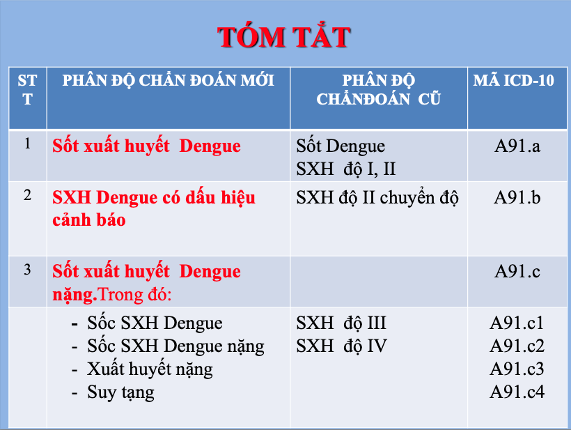

dengue severity classification table

to match between the severity and its ICD-10 code.

```r
icd10_rows %<>% mutate(
  severity = case_when(
    subclass == "a" ~ "dengue",
    subclass == "b" ~ "dengue with warning signs",
    subclass %in% c("c", "c1", "c2") ~ "severe dengue",
    .default = severity
  )
)
icd10_rows
```

```
## # A tibble: 7,979 × 5
##    id             severity full  class subclass
##    <chr>          <chr>    <chr> <chr> <chr>
##  1 1010737574543  dengue   a91.a a91   a
##  2 1011113266269  dengue   a91.a a91   a
##  3 10111151119539 dengue   a91.a a91   a
##  4 1014166330622  dengue   a91.a a91   a
##  5 1014933508390  dengue   a91.a a91   a
##  6 1061139229308  dengue   a91.a a91   a
##  7 1061141212116  dengue   a91.a a91   a
##  8 1061211218348  dengue   a91.a a91   a
##  9 1090213573281  dengue   a91.a a91   a
## 10 1090501235552  dengue   a91.a a91   a
## # … with 7,969 more rows
```

- And then we will copy the severity back over to the main dataframe using record IDs.

```r
# Before
incidence_df %>%
  group_by(severity) %>%
  summarise(total = n())
```

```
## # A tibble: 4 × 2
##   severity                   total
##   <chr>                      <int>
## 1 dengue                     67304
## 2 dengue with warning signs   9085
## 3 severe dengue               1892
## 4 <NA>                      243622
```

```r
# Impute `severity` based on ICD-10 classifications extracted from `notes`
incidence_df %<>%
  left_join(
    icd10_rows %>% select(id, severity),
    by = "id"
  ) %>%
  mutate(severity = ifelse(is.na(severity.x), severity.y, severity.x), .keep = "unused")

# After
incidence_df %>%
  group_by(severity) %>%
  summarise(total = n())
```

```
## # A tibble: 4 × 2
##   severity                   total
##   <chr>                      <int>
## 1 dengue                     72497
## 2 dengue with warning signs  11601
## 3 severe dengue               2341
## 4 <NA>                      235552
```

# IV. Exploratory data analysis / Visualization

## a. Time series

### Dengue incidence

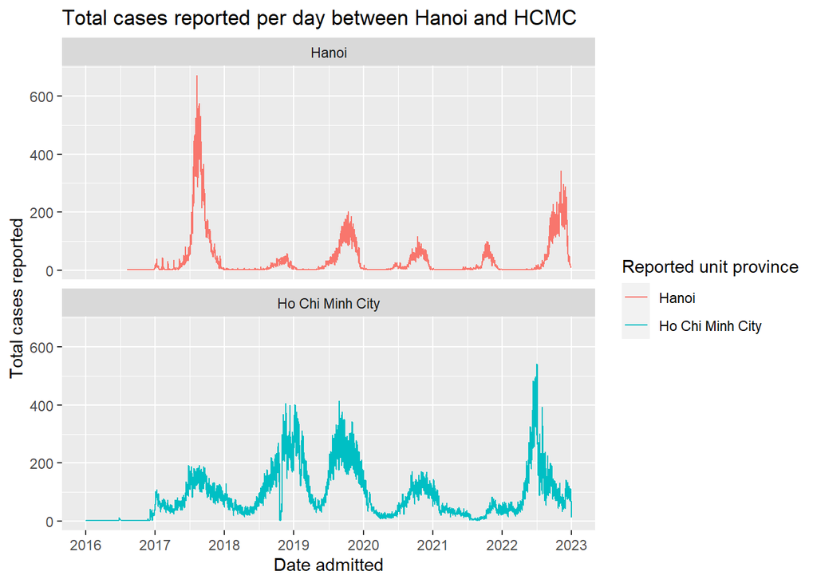

```r
incidence_time <- incidence_df %>%
  select(id, date_admitted, reported_unit_province) %>%
  mutate(
    year = format(date_admitted, "%Y") %>% as.integer(),
    reported_unit_province = recode(
      reported_unit_province,
      "hồ chí minh" = "Ho Chi Minh City", "hà nội" = "Hanoi"
    )
  ) %>%
  filter(
    year < 2023, year > 2015,
    reported_unit_province %in% c("Ho Chi Minh City", "Hanoi")
  )

incidence_time_grouped <- incidence_time %>%
  group_by(date_admitted, reported_unit_province) %>%
  summarise(total = n())

incidence_ts_p <- ggplot(
  incidence_time_grouped,
  aes(
    x = date_admitted,
    y = total,
    color = reported_unit_province
  )
) +
  geom_line() +
  scale_x_date(date_breaks = "1 year", date_labels = "%Y") +
  labs(
    title = "Total cases reported per day between Hanoi and HCMC",
    color = "Reported unit province"
  ) +
  xlab("Date admitted") +
  ylab("Total cases reported") +
  facet_wrap(~reported_unit_province, ncol = 1)
incidence_ts_p
```

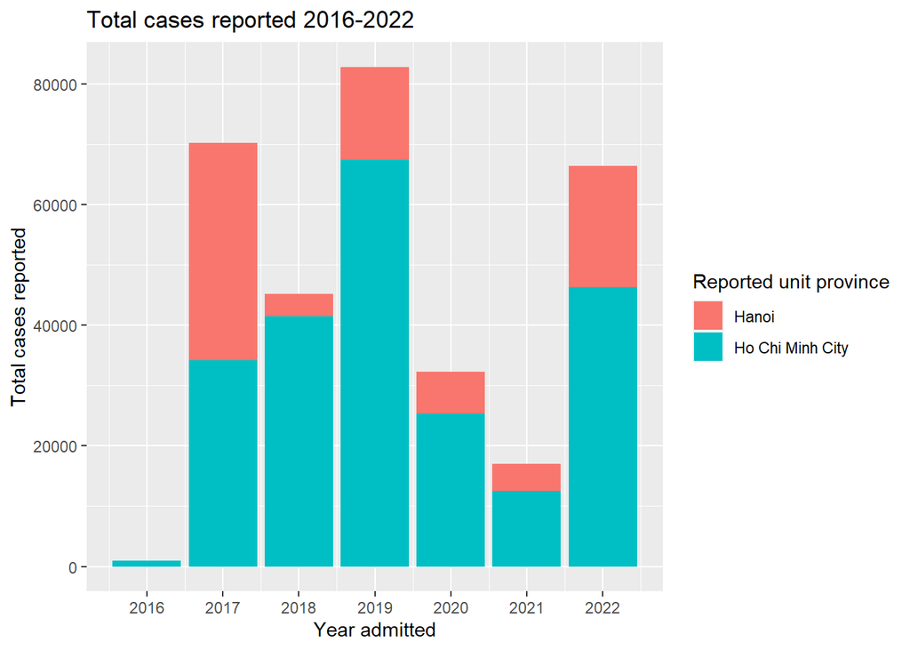

```r
incidence_time %>%
  group_by(year, reported_unit_province) %>%
  summarise(total = n()) %>%
  ggplot(aes(fill = reported_unit_province, y = total, x = year)) +
  geom_bar(position = "stack", stat = "identity") +
  labs(
    title = "Total cases reported 2016-2022",
    fill = "Reported unit province"
  ) +
  xlab("Year admitted") +
  ylab("Total cases reported") +
  scale_x_continuous(
    breaks = seq(2016, 2022),
    labels = c("2016", "2017", "2018", "2019", "2020", "2021", "2022")
  )
```

### Incidence with entomology from Moritz’s group

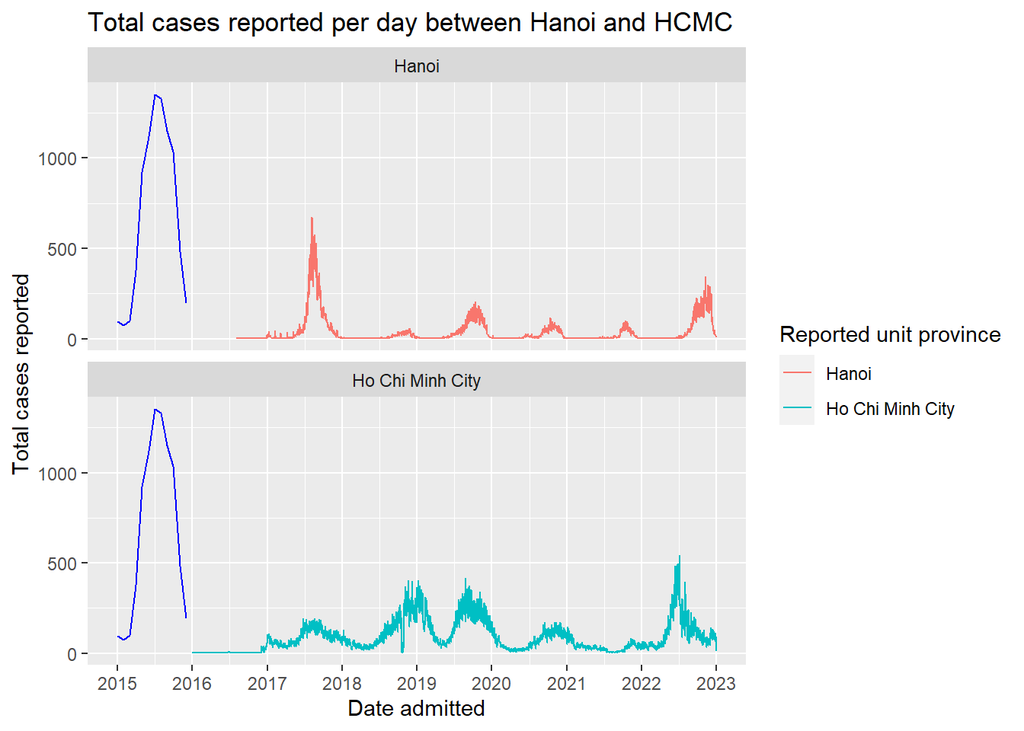

```r
ento_df1 <- read_csv("../entomology/aedes_vietnam_admin3_raw.csv", show_col_types = FALSE) %>%
  select(GID_3, starts_with("Aegypti_")) %>%
  pivot_longer(!GID_3, names_to = "month_str", values_to = "value") %>%
  group_by(month_str) %>%
  summarise(total = sum(value, na.rm = TRUE)) %>%
  mutate(
    rgx = str_match_all(month_str, r"{Aegypti_(\w{3})normal}") %>%
      lapply(apply, 1, paste0, collapse = "|") %>%
      lapply(first)
  ) %>%
  separate(rgx, into = c("full", "month"), sep = "\\|") %>%
  mutate(month = fast_strptime(paste0(month, "-2015"), "%b-%Y") %>% as_date()) %>%
  select(month, total)

incidence_ts_p + geom_line(data = ento_df1, aes(x = month, y = total), color = "blue")
```

### Incidence with entomology from Sophie’s group

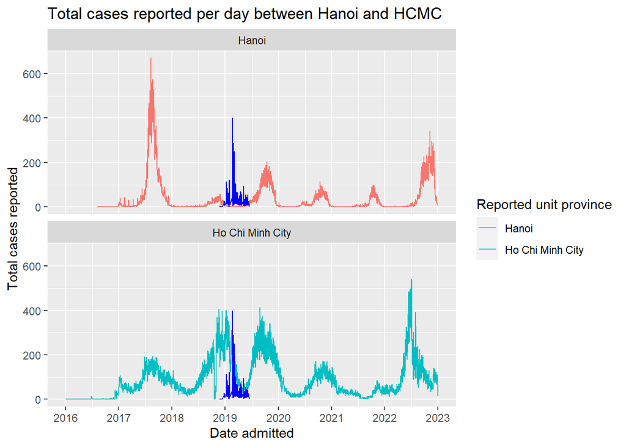

```r
ento_df2 <- read_csv("../entomology/entomology_sophie_group.csv", show_col_types = FALSE) %>%
  group_by(date) %>%
  summarise(total = sum(total_number, na.rm = TRUE))

incidence_ts_p +
  geom_line(
    data = ento_df2,
    aes(x = date, y = scales::rescale(total, to = c(0, 400))),
    color = "blue"
  )
```

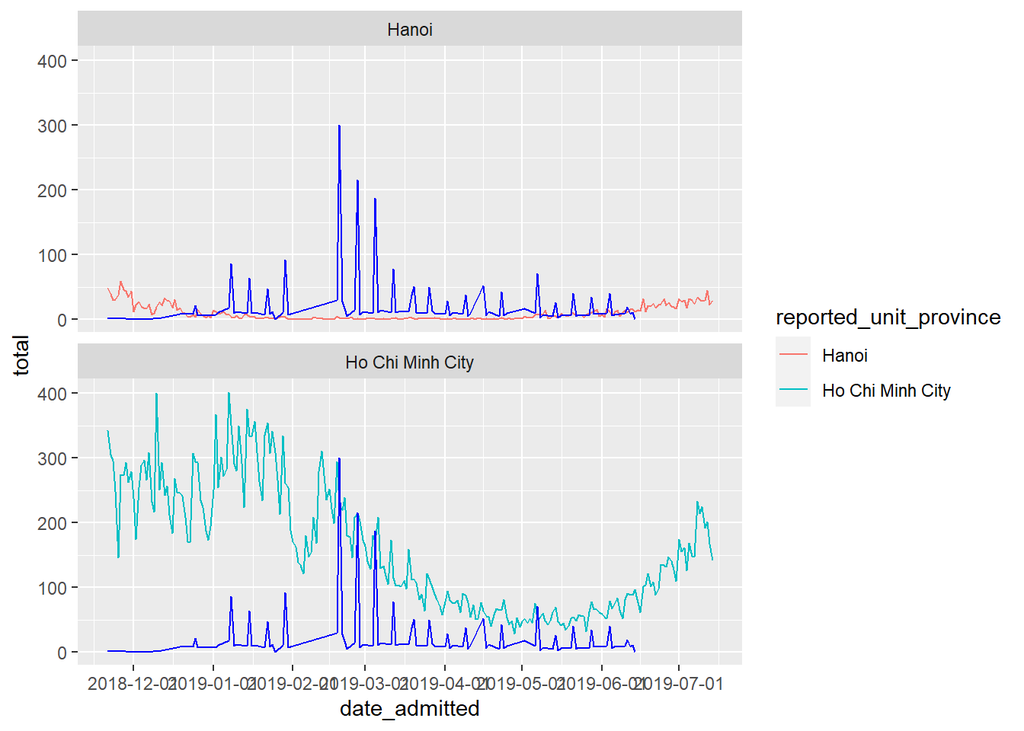

```r
ggplot(
  incidence_time_grouped %>%
    filter(
      date_admitted <= max(ento_df2$date) %m+% months(1),
      date_admitted >= min(ento_df2$date)
    ),
  aes(x = date_admitted, y = total, color = reported_unit_province)
) +
  geom_line() +
  scale_x_date(date_breaks = "1 month") +
  facet_wrap(~reported_unit_province, ncol = 1) +
  geom_line(
    data = ento_df2,
    aes(x = date, y = scales::rescale(total, to = c(0, 300))),
    color = "blue"
  )
```

### Year-age quantiles

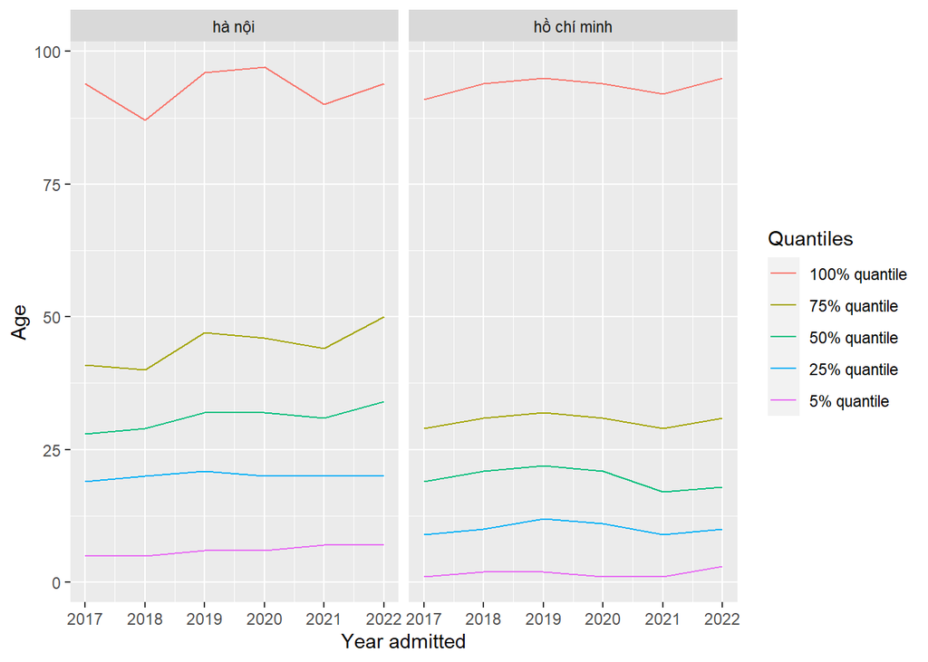

```r
year_age_quantiles <- incidence_df %>%
  mutate(year_admitted = year(date_admitted)) %>%
  group_by(year_admitted, reported_unit_province) %>%
  filter(
    age >= 0, age < 100,
    year_admitted > 2016, year_admitted < 2023,
    reported_unit_province %in% c("hồ chí minh", "hà nội")
  ) %>%
  summarise(
    quant5 = quantile(age, probs = .05),
    quant25 = quantile(age, probs = .25),
    quant50 = quantile(age, probs = .5),
    quant75 = quantile(age, probs = .75),
    quant100 = quantile(age, probs = 1)
  ) %>%
  ungroup() %>%
  pivot_longer(!c(year_admitted, reported_unit_province)) %>%
  mutate(name = factor(
    name,
    levels = c("quant5", "quant25", "quant50", "quant75", "quant100")
  ))

year_age_quantiles %>%
  ggplot(aes(x = year_admitted, y = value, group = name, color = name)) +
  geom_line() +
  ylab("Age") +
  xlab("Year admitted") +
  labs(color = "Quantiles") +
  scale_color_discrete(
    labels = c(
      "quant100" = "100% quantile",
      "quant75" = "75% quantile",
      "quant50" = "50% quantile",
      "quant25" = "25% quantile",
      "quant5" = "5% quantile"
    ),
    limits = rev
  ) +
  facet_wrap(~reported_unit_province)
```

### Year-age rolling quantiles (1-month)

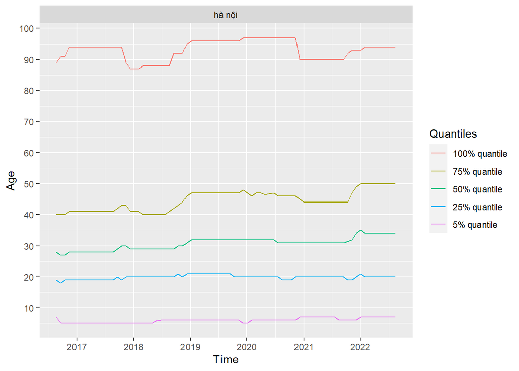

```r
weeks <- incidence_df %>%
  filter(
    reported_unit_province %in% c("tp. h.c.m", "hà nội")
  ) %>%
  mutate(
    week_admitted = floor_date(date_admitted, "week")
  ) %>%
  select(age, week_admitted, reported_unit_province)

window_width <- 52 # in weeks
rolling_step <- 4 # in weeks

left_ticks <- seq(
  floor_date(ymd("2017-01-01"), "week") - weeks(floor(window_width / 2)),
  floor_date(ymd("2023-01-01"), "week") - weeks(floor(window_width / 2)),
  by = sprintf("%d weeks", rolling_step)
)

rolling_quantile_df <- tibble(
  center_week = Date(),
  quant5 = double(),
  quant25 = double(),
  quant50 = double(),
  quant75 = double(),
  quant100 = double(),
  reported_unit_province = character()
)

for (ltick in as.list(left_ticks)) {
  low <- ltick
  high <- ltick + weeks(window_width)

  quant_w_unit <- weeks %>%
    filter(week_admitted < high, week_admitted > low) %>%
    select(age, reported_unit_province) %>%
    group_by(reported_unit_province) %>%
    summarise(
      quant5 = quantile(age, probs = .05),
      quant25 = quantile(age, probs = .25),
      quant50 = quantile(age, probs = .5),
      quant75 = quantile(age, probs = .75),
      quant100 = quantile(age, probs = 1)
    ) %>%
    mutate(center_week = low + dweeks(7))

  rolling_quantile_df %<>% bind_rows(quant_w_unit)
}


rolling_quantile_df %>%
  pivot_longer(!c(center_week, reported_unit_province)) %>%
  mutate(name = factor(
    name,
    levels = c("quant5", "quant25", "quant50", "quant75", "quant100")
  )) %>%
  ggplot(
    aes(x = center_week, y = value, group = name, color = name)
  ) +
  geom_line() +
  ylab("Age") +
  xlab("Time") +
  labs(color = "Quantiles") +
  scale_color_discrete(
    labels = c(
      "quant100" = "100% quantile",
      "quant75" = "75% quantile",
      "quant50" = "50% quantile",
      "quant25" = "25% quantile",
      "quant5" = "5% quantile"
    ),
    limits = rev
  ) +
  scale_x_date(date_breaks = "1 year", date_labels = "%Y") +
  scale_y_continuous(breaks = seq(0, 100, by = 10)) +
  facet_wrap(~reported_unit_province)
```

## b. Maps (Province level)

### Patients’ address (log transformed)

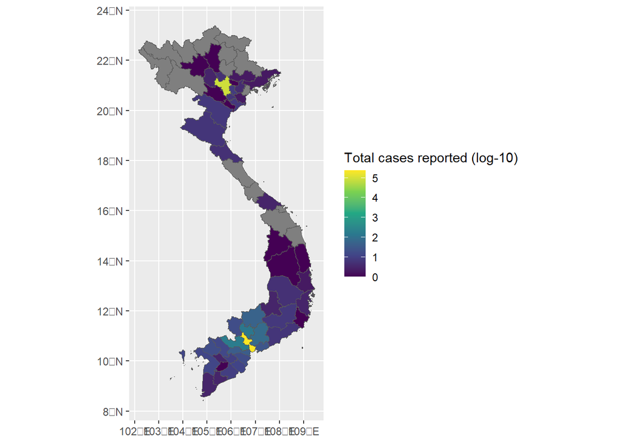

```r
incidence_lvl1 <- incidence_df %>%
  select(id, province) %>%
  group_by(province) %>%
  summarise(total = n())

shape_lvl1 %>%
  left_join(incidence_lvl1, by = c("NAME_1" = "province")) %>%
  ggplot() +
  geom_sf(aes(fill = log10(total))) +
  scale_fill_viridis_c() +
  labs(fill = "Total cases reported (log-10)")
```

### Incidences reported at HCMC

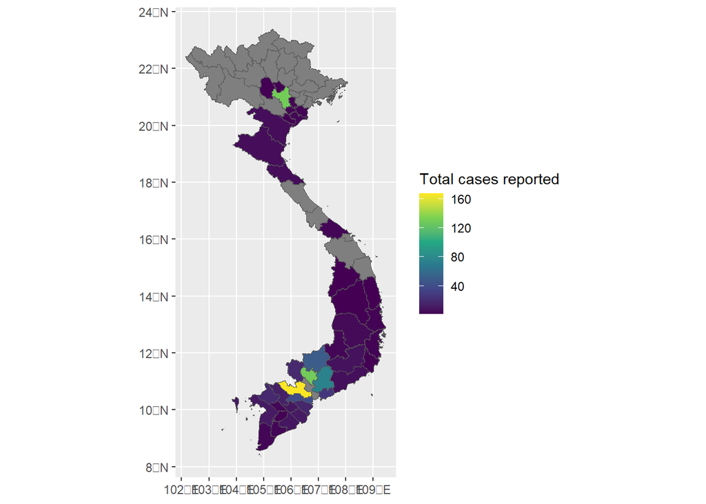

```r
incidence_to_hcmc <- incidence_df %>%
  select(id, province, reported_unit_province) %>%
  filter(reported_unit_province == "hồ chí minh") %>%
  group_by(province) %>%
  summarise(total = n()) %>%
  filter(province != "hồ chí minh")

shape_lvl1 %>%
  left_join(incidence_to_hcmc, by = c("NAME_1" = "province")) %>%
  ggplot() +
  geom_sf(aes(fill = total)) +
  scale_color_viridis_c() +
  scale_fill_viridis_c() +
  labs(fill = "Total cases reported")
```

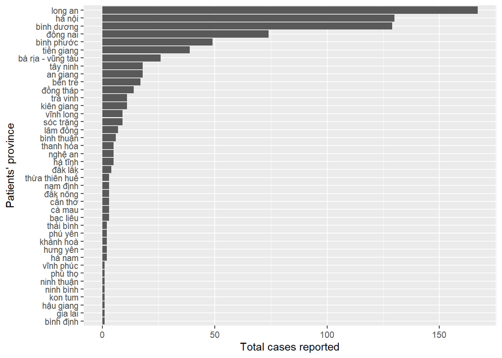

```r
incidence_to_hcmc %>%
  ggplot() +
  geom_col(aes(x = total, y = reorder(province, total))) +
  xlab("Total cases reported") +
  ylab("Patients' province")
```

### Incidences reported at Hanoi

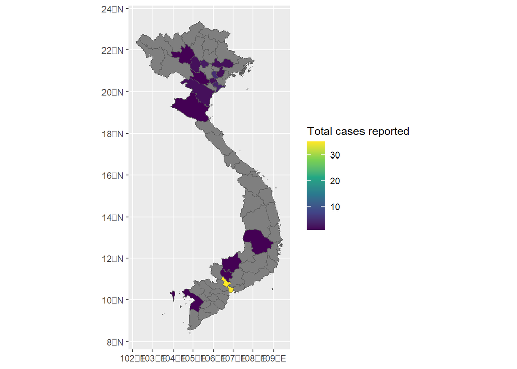

```r
incidence_to_hanoi <- incidence_df %>%
  select(id, province, reported_unit_province) %>%
  filter(reported_unit_province == "hà nội") %>%
  group_by(province) %>%
  summarise(total = n()) %>%
  filter(province != "hà nội")

shape_lvl1 %>%
  left_join(incidence_to_hanoi, by = c("NAME_1" = "province")) %>%
  ggplot() +
  geom_sf(aes(fill = total)) +
  scale_color_viridis_c() +
  scale_fill_viridis_c() +
  labs(fill = "Total cases reported")
```

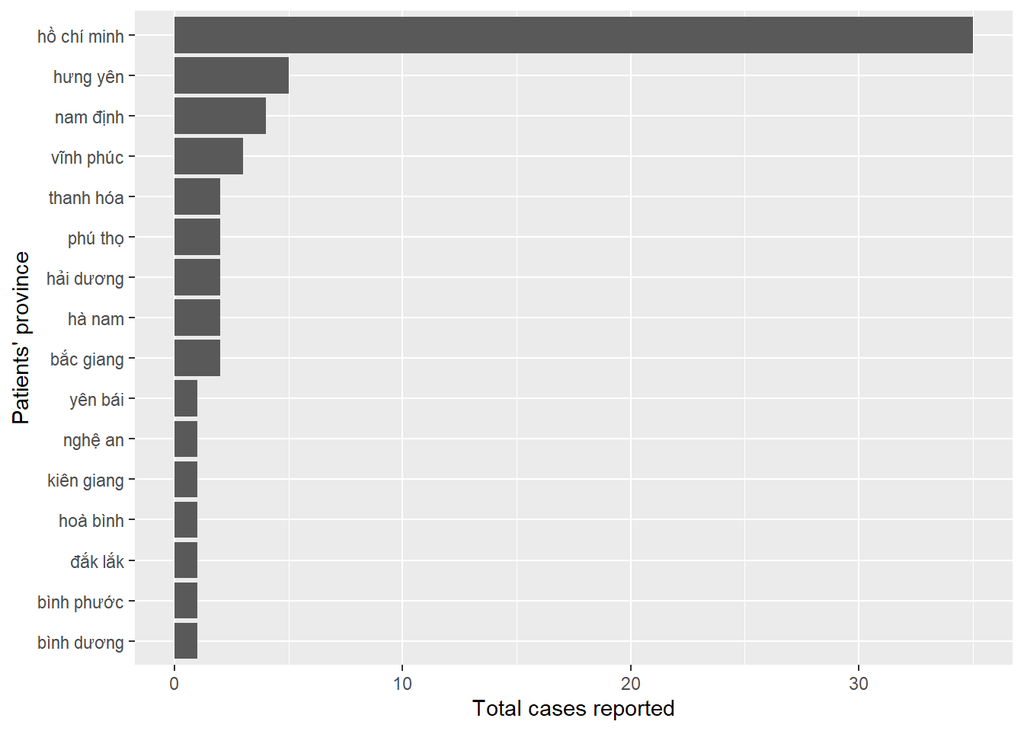

```r
incidence_to_hanoi %>%
  ggplot() +
  geom_col(aes(x = total, y = reorder(province, total))) +
  xlab("Total cases reported") +
  ylab("Patients' province")
```

## c. Maps (District level)

### Patients’ address (log transformed)

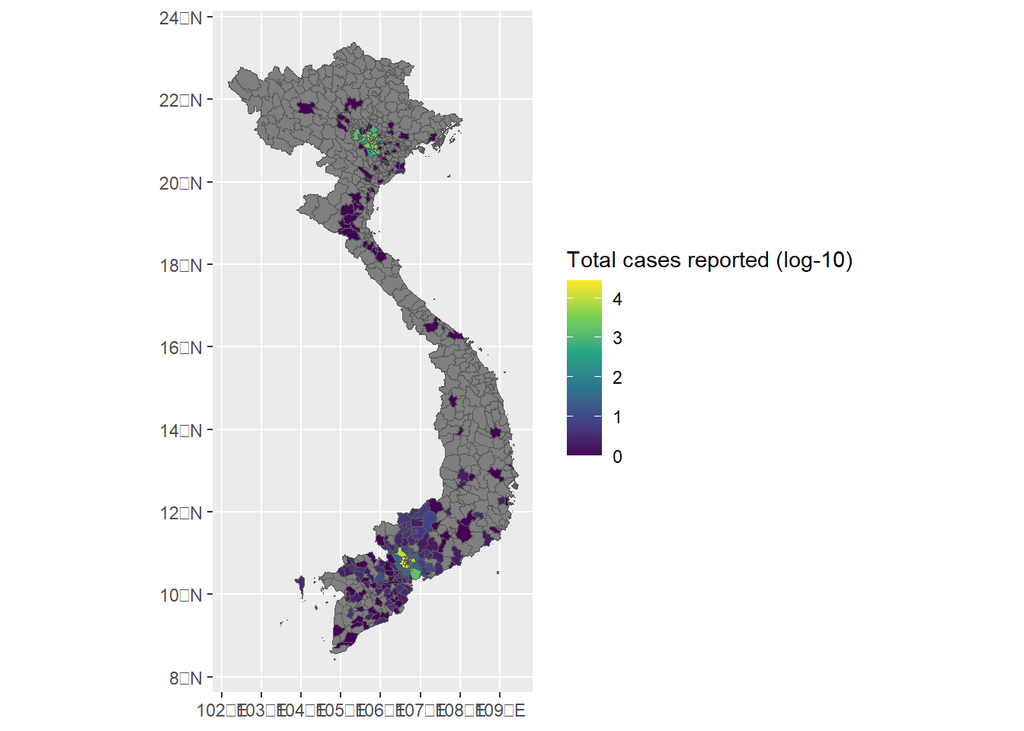

```r
shape_lvl2 <- readRDS("./gadm41_VNM_2_pk.rds") %>%
  terra::unwrap() %>%
  st_as_sf()

shape_lvl2 %<>%
  select(c(GID_2, NAME_1, NAME_2)) %>%
  mutate_at(c("NAME_1", "NAME_2"), tolower) %>%
  mutate_at(c("NAME_1", "NAME_2"), ~ str_replace_all(.x, "hòa", "hoà")) %>%
  mutate(
    NAME_2 = recode(NAME_2, "mù căng chải" = "mù cang chải"),
    NAME_2 = str_remove(NAME_2, "(thành phố|quận|thị xã|huyện)")
  ) %>%
  mutate(across(where(is.character), str_trim)) %>%
  mutate(full_name = paste0(NAME_1, ", ", NAME_2))

incidence_lvl2_no_group <- incidence_df %>%
  select(id, province, district) %>%
  mutate(
    regex = str_match_all(district, r"{^(thành phố|quận|thị xã|huyện)(.+)$}") %>%
      lapply(apply, 1, paste0, collapse = "|") %>%
      lapply(first)
  ) %>%
  separate(regex, into = c("full", "dlevel", "dname"), sep = "\\|") %>%
  mutate(across(where(is.character), str_trim)) %>%
  mutate(full_name = paste0(province, ", ", dname))

incidence_lvl2 <- incidence_lvl2_no_group %>%
  group_by(full_name) %>%
  summarise(total = n())

shape_lvl2 %>%
  left_join(incidence_lvl2, by = "full_name") %>%
  ggplot() +
  geom_sf(aes(fill = log10(total))) +
  scale_fill_viridis_c() +
  labs(fill = "Total cases reported (log-10)")
```

### Patients’ address HCMC-zoomed

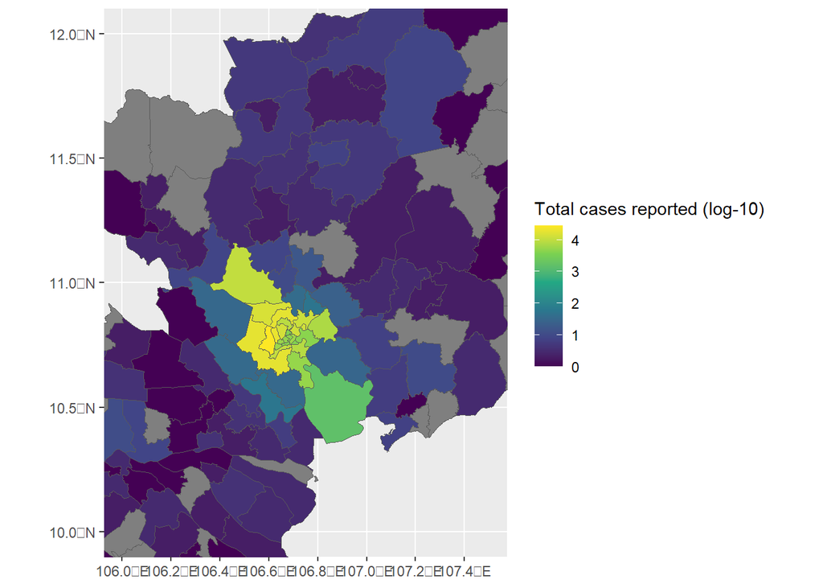

```r
shape_lvl2 %>%
  left_join(incidence_lvl2, by = "full_name") %>%
  ggplot() +
  geom_sf(aes(fill = log10(total))) +
  scale_fill_viridis_c() +
  labs(fill = "Total cases reported (log-10)") +
  coord_sf(xlim = c(106, 107.5), ylim = c(10, 12))
```

### Patients’ address Hanoi-zoomed

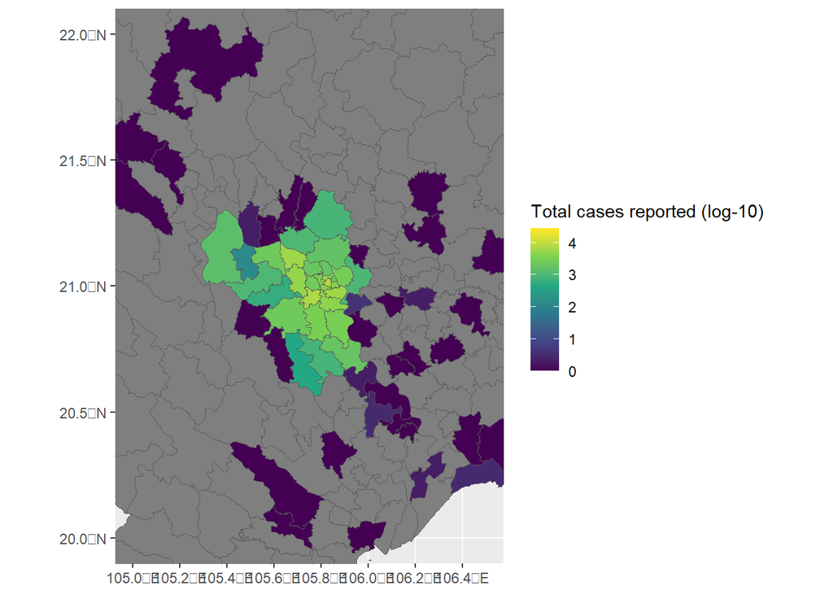

```r
shape_lvl2 %>%
  left_join(incidence_lvl2, by = "full_name") %>%
  ggplot() +
  geom_sf(aes(fill = log10(total))) +
  scale_fill_viridis_c() +
  labs(fill = "Total cases reported (log-10)") +
  coord_sf(xlim = c(105, 106.5), ylim = c(20, 22))
```

## d. Maps (Commune level)

### Patients’ address (log transformed)

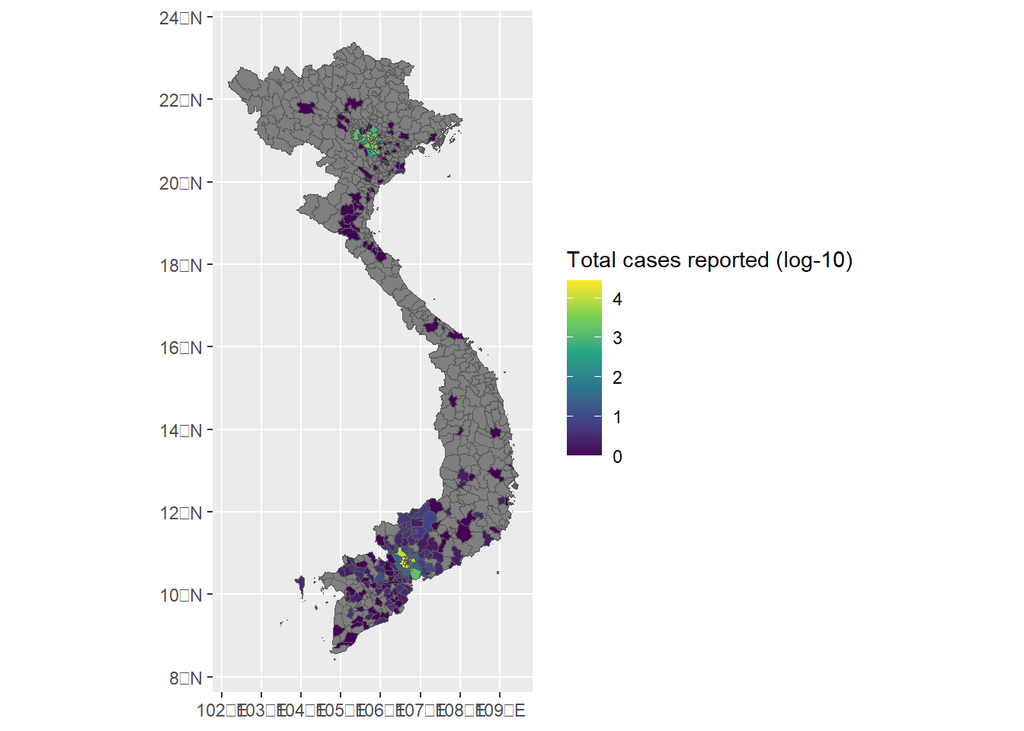

```r
shape_lvl3 <- readRDS("./gadm41_VNM_3_pk.rds") %>%
  terra::unwrap() %>%
  st_as_sf()

shape_lvl3 %<>%
  select(c(GID_2, NAME_1, NAME_2, NAME_3)) %>%
  mutate_at(c("NAME_1", "NAME_2", "NAME_3"), tolower) %>%
  mutate(
    across(c(NAME_1, NAME_2, NAME_3), .fns = ~ str_replace_all(.x, "hoà", "hòa")),
    NAME_2 = str_remove(NAME_2, "(thành phố|quận|thị xã|huyện)"),
    NAME_3 = str_remove(NAME_3, "(phường|xã|thị trấn)")
  ) %>%
  mutate(across(where(is.character), str_trim)) %>%
  mutate(full_name = paste0(NAME_1, ", ", NAME_2, ", ", NAME_3))

incidence_lvl3_no_group <- incidence_df %>%
  select(id, province, district, commune) %>%
  mutate(
    commune = str_replace_all(commune, "ð", "đ"),
    dregex = str_match_all(district, r"{^(thành phố|quận|thị xã|huyện)(.+)$}") %>%
      lapply(apply, 1, paste0, collapse = "|") %>%
      lapply(first),
    cregex = str_match_all(commune, r"{^(phường|xã|thị trấn)(.+)$}") %>%
      lapply(apply, 1, paste0, collapse = "|") %>%
      lapply(first)
  ) %>%
  separate(dregex, into = c("dfull", "dlevel", "dname"), sep = "\\|") %>%
  separate(cregex, into = c("cfull", "clevel", "cname"), sep = "\\|") %>%
  mutate(across(where(is.character), str_trim)) %>%
  mutate(full_name = paste0(province, ", ", dname, ", ", cname))

incidence_lvl3 <- incidence_lvl3_no_group %>%
  group_by(full_name) %>%
  summarise(total = n())

# using lvl2 here since lvl3 is too small
shape_lvl2 %>%
  left_join(incidence_lvl2, by = "full_name") %>%
  ggplot() +
  geom_sf(aes(fill = log10(total))) +
  labs(fill = "Total cases reported (log-10)") +
  scale_fill_viridis_c()
```

### Patients’ address HCMC-zoomed

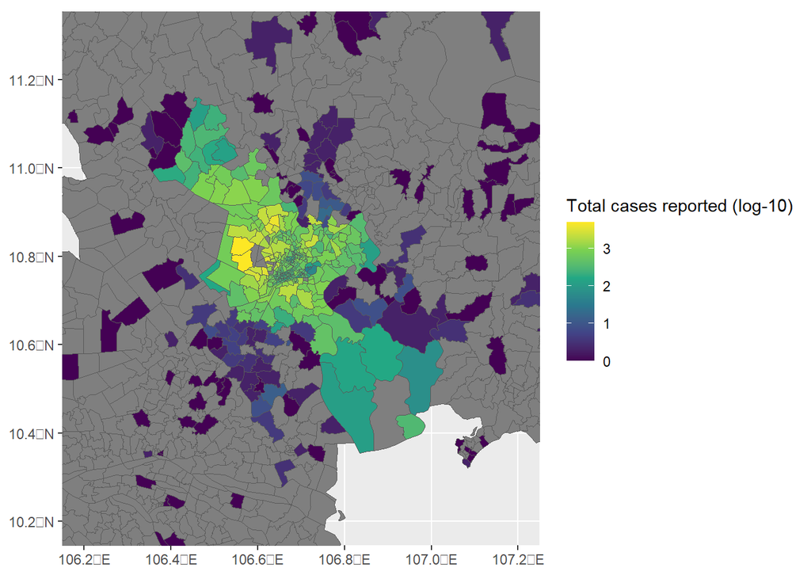

```r
shape_lvl3 %>%
  left_join(incidence_lvl3, by = "full_name") %>%
  ggplot() +
  geom_sf(aes(fill = log10(total))) +
  scale_fill_viridis_c() +
  labs(fill = "Total cases reported (log-10)") +
  coord_sf(xlim = c(106.2, 107.2), ylim = c(10.2, 11.3))
```

### Patients’ address Hanoi-zoomed

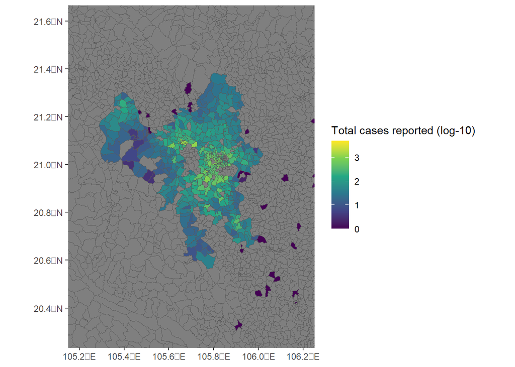

```r
shape_lvl3 %>%
  left_join(incidence_lvl3, by = "full_name") %>%
  ggplot() +
  geom_sf(aes(fill = log10(total))) +
  scale_fill_viridis_c() +
  labs(fill = "Total cases reported (log-10)") +
  coord_sf(xlim = c(105.2, 106.2), ylim = c(20.3, 21.6))
```

## e. Misc

### Age-location pyramid

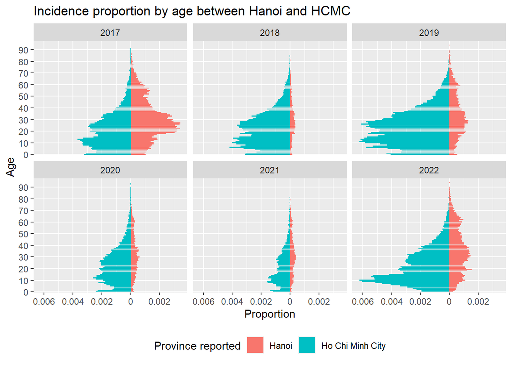

```r
age_loc_df <- incidence_df %>%
  mutate(year_admitted = year(date_admitted)) %>%
  group_by(age, reported_unit_province, year_admitted) %>%
  summarise(total = n()) %>%
  filter(
    age >= 0, age < 100,
    reported_unit_province %in% c("hồ chí minh", "hà nội"),
    year_admitted > 2016, year_admitted < 2023
  ) %>%
  group_by(reported_unit_province, year_admitted) %>%
  mutate(
    total = total / 303592
  ) %>%
  mutate(
    total = ifelse(reported_unit_province == "hồ chí minh", -total, total),
    age = factor(age),
    reported_unit_province = recode(
      reported_unit_province,
      "hồ chí minh" = "Ho Chi Minh City", "hà nội" = "Hanoi"
    )
  )

total_range <- range(age_loc_df$total)

age_loc_p <- age_loc_df %>%
  ggplot(aes(x = total, y = age, fill = reported_unit_province)) +
  geom_col() +
  scale_x_continuous(
    breaks = pretty(total_range),
    labels = abs(pretty(total_range))
  ) +
  scale_y_discrete(breaks = pretty(range(0, 99), n = 10)) +
  theme(legend.position = "bottom") +
  xlab("Proportion") +
  ylab("Age") +
  labs(
    title = "Incidence proportion by age between Hanoi and HCMC",
    fill = "Province reported"
  )
age_loc_p +
  facet_wrap(~year_admitted)
```

```r
# ggsave(
#   "incidence_prop.png",
#   age_loc_p +
#     facet_wrap(~year_admitted)
# )
#
# age_loc_p +
#   labs(
#     title = "Incidence proportion by age between Hanoi and HCMC\nYear: {frame_time}"
#   ) +
#   gganimate::transition_time(year_admitted) +
#   gganimate::ease_aes("cubic-in-out")
```

### Patients’ reported condition

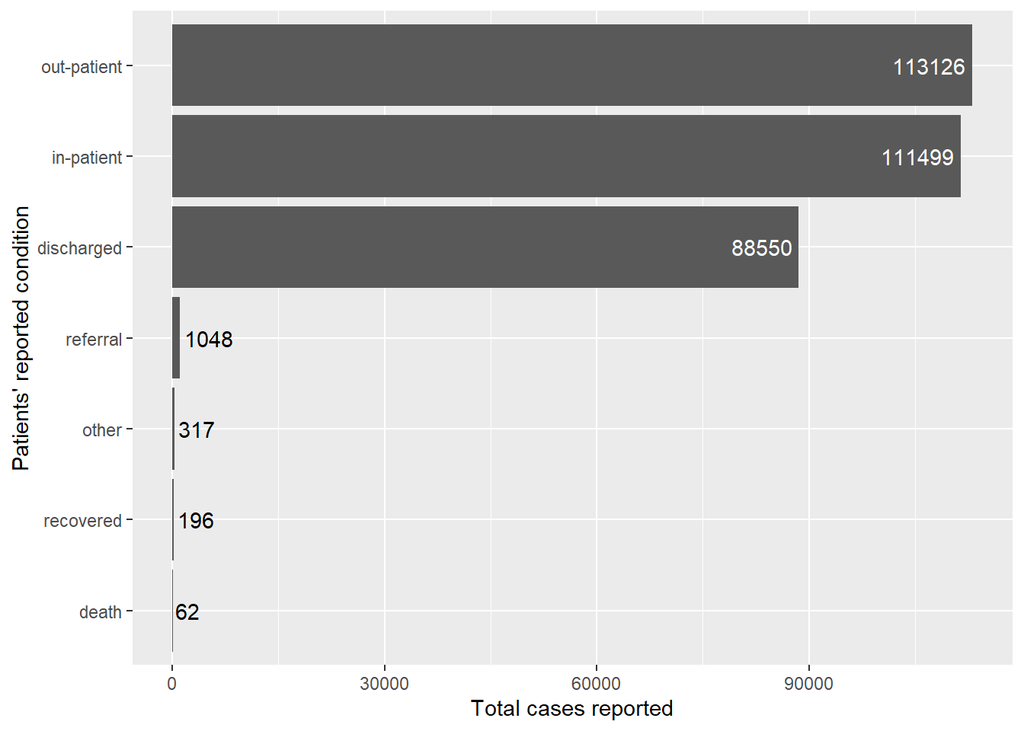

```r
patient_condition_df <- incidence_df %>%
  select(id, current_condition, reported_unit_province, age) %>%
  filter(
    age >= 0, age < 100,
    reported_unit_province %in% c("hồ chí minh", "hà nội")
  )

patient_condition_grouped_df <- patient_condition_df %>%
  group_by(current_condition) %>%
  summarise(total = n())

ggplot(patient_condition_grouped_df) +
  geom_col(aes(x = total, y = reorder(current_condition, total))) +
  geom_text(
    data = subset(patient_condition_grouped_df, total < 5000),
    aes(x = total, y = reorder(current_condition, total), label = total),
    hjust = -0.1
  ) +
  geom_text(
    data = subset(patient_condition_grouped_df, total > 5000),
    aes(x = total, y = reorder(current_condition, total), label = total),
    hjust = 1.1, color = "white"
  ) +
  xlab("Total cases reported") +
  ylab("Patients' reported condition")
```

### Population over time

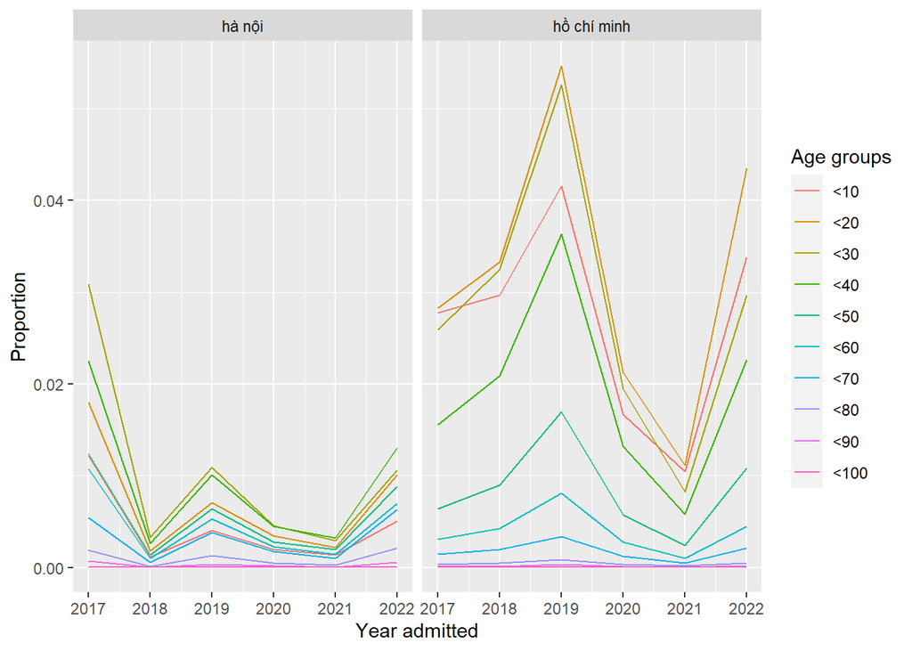

```r
age_group_pop_df <- incidence_df %>%
  mutate(year_admitted = year(date_admitted)) %>%
  filter(
    age >= 0, age < 100,
    reported_unit_province %in% c("hồ chí minh", "hà nội"),
    year_admitted > 2016, year_admitted < 2023
  ) %>%
  mutate(
    age_group = case_when(
      age < 10 ~ "<10",
      age < 20 ~ "<20",
      age < 30 ~ "<30",
      age < 40 ~ "<40",
      age < 50 ~ "<50",
      age < 60 ~ "<60",
      age < 70 ~ "<70",
      age < 80 ~ "<80",
      age < 90 ~ "<90",
      age < 100 ~ "<100"
    ) %>%
      factor(levels = c(
        "<10", "<20", "<30", "<40", "<50", "<60", "<70", "<80", "<90", "<100"
      ))
  )

age_group_pop_df %>%
  group_by(age_group, year_admitted, reported_unit_province) %>%
  summarise(count = n()) %>%
  ungroup() %>%
  mutate(total = sum(count)) %>%
  ggplot(aes(x = year_admitted, y = count / total, group = age_group, color = age_group)) +
  geom_line() +
  facet_wrap(~reported_unit_province) +
  ylab("Proportion") +
  xlab("Year admitted") +
  labs(color = "Age groups")
```

### Date of admission vs reported time

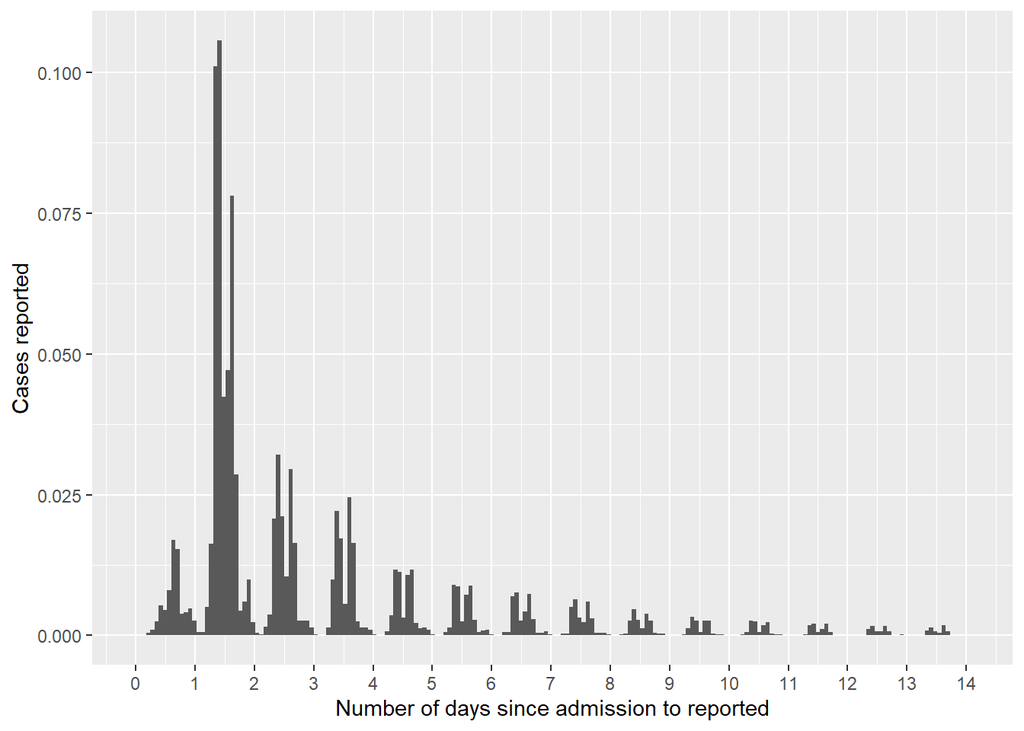

```r
incidence_df %>%
  mutate(
    time_diff = difftime(reported_time, date_admitted, units = "days") %>% as.double()
  ) %>%
  select(id, time_diff) %>%
  filter(time_diff < 14.1, time_diff > 0) %>%
  ggplot() +
  geom_histogram(
    aes(
      x = time_diff,
      y = after_stat(count) / sum(after_stat(count))
    ),
    bins = 200
  ) +
  xlab("Number of days since admission to reported") +
  ylab("Cases reported") +
  scale_x_continuous(breaks = seq(0, 14))
```

Cumulative sum version

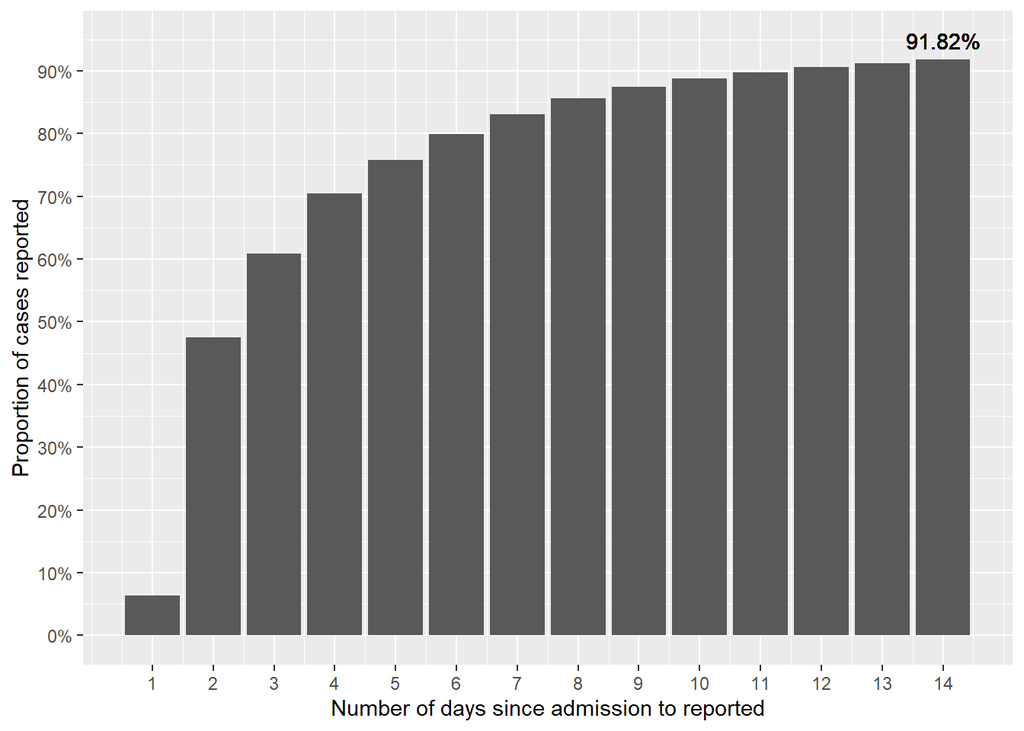

```r
csum_df <- incidence_df %>%
  mutate(
    time_diff = difftime(reported_time, date_admitted, units = "days") %>% as.double() %>% ceiling()
  ) %>%
  select(id, time_diff) %>%
  filter(time_diff < 14.1, time_diff > 0) %>%
  group_by(time_diff) %>%
  summarise(count = n()) %>%
  mutate(csum = cumsum(count), total = incidence_df %>% nrow())

csum_df %>%
  ggplot() +
  geom_col(aes(x = time_diff, y = csum / total)) +
  xlab("Number of days since admission to reported") +
  ylab("Proportion of cases reported") +
  scale_x_continuous(breaks = seq(1, 14)) +
  scale_y_continuous(labels = scales::percent, breaks = seq(0, 1, by = 0.1)) +
  geom_text(
    x = 14,
    aes(
      y = max(csum) / total + 0.03,
      label = sprintf("%.2f%%", max(csum) / total * 100)
    )
  )
```

### Incidence reported severity against reported condition

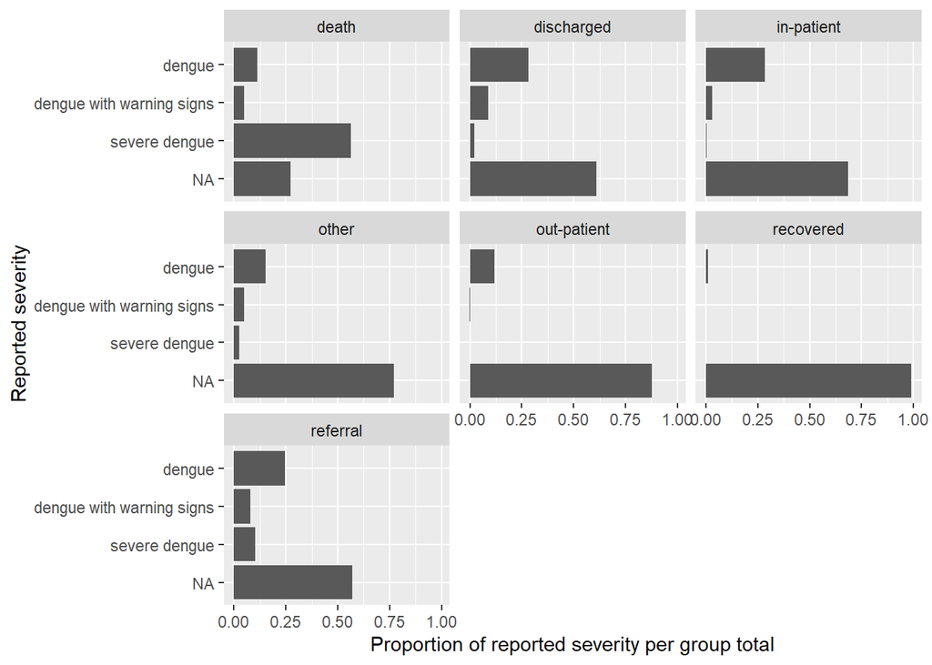

```r
incidence_df %>%
  mutate(
    severity = case_when(is.na(severity) ~ "NA", .default = severity),
    severity = factor(
      severity,
      levels = c("dengue", "dengue with warning signs", "severe dengue", "NA")
    )
  ) %>%
  count(current_condition, severity) %>%
  group_by(current_condition) %>%
  mutate(grouped_total = sum(n)) %>%
  ggplot() +
  geom_col(
    aes(
      y = reorder(severity, -as.numeric(severity)),
      x = n / grouped_total,
      group = current_condition
    )
  ) +
  facet_wrap(~current_condition) +
  scale_x_continuous("Proportion of reported severity per group total") +
  scale_y_discrete("Reported severity")
```